# Caso 2

Regiane Canisares França

01 de dezembro de 2020

## 1) Evolução mensal e anual das exportações brasileiras das commodities: soja, farelo de soja e óleo de soja

A evolução das exportações brasileiras dos produtos de soja (soybean, soybean meal e soybean oil) pode ser visualizada nas tabelas e gráficos a seguir. Os dados foram transformados em milhões de toneladas para melhor visualização.

```r
# Pacotes necessários
library(urca)
library(vars)
library(tseries)
```

```r
library(plyr)
library(forecast)
library(ggplot2)
```

```r
# Extraindo os dados da base

dados<-read.csv("data_comexstat.csv")
soybeans_export_tons<-subset(dados, product == "soybeans" & type == "Export") [,c("date","tons")]
soybeans_total_tons<-ddply(soybeans_export_tons, c("date"),summarise,soybeans_tons=(sum(tons))/1000000)
soybeans_total_tons$date<-as.Date(soybeans_total_tons$date)
soybeans_total_tons["Ano"]<-lubridate::year(soybeans_total_tons$date)
soybeans_total_tons<-ddply(soybeans_total_tons, c("Ano"),summarise,soybeans_tons=sum(soybeans_tons))

soybeansOil_export_tons<- subset(dados, product == "soybean_oil" & type == "Export") [,c("date","tons")]
soybeansOil_total_tons<-ddply(soybeansOil_export_tons, c("date"),summarise,soybeansOil_tons=(sum(tons))/1000000)
soybeansOil_total_tons$date<-as.Date(soybeansOil_total_tons$date)
soybeansOil_total_tons["Ano"]<-lubridate::year(soybeansOil_total_tons$date)
soybeansOil_total_tons<-ddply(soybeansOil_total_tons, c("Ano"),summarise,soybeansOil_tons=sum(soybeansOil_tons))

soybeansMeal_export_tons<- subset(dados, product == "soybean_meal" & type == "Export") [,c("date","tons")]
soybeansMeal_total_tons<-ddply(soybeansMeal_export_tons, c("date"),summarise,soybeansMeal_tons=(sum(tons))/1000000)
soybeansMeal_total_tons$date<-as.Date(soybeansMeal_total_tons$date)
soybeansMeal_total_tons["Ano"]<-lubridate::year(soybeansMeal_total_tons$date)
soybeansMeal_total_tons<-ddply(soybeansMeal_total_tons, c("Ano"),summarise,soybeansMeal_tons=sum(soybeansMeal_tons))

dados1<-soybeans_total_tons
dados1["SoybeansOil_Mtons"]<-soybeansOil_total_tons$soybeansOil_tons
dados1["SoybeansMeal_Mtons"]<-soybeansMeal_total_tons$soybeansMeal_tons

names(dados1)[2]<-"Soybeans_Mtons"
dados1
```

```
##     Ano Soybeans_Mtons SoybeansOil_Mtons SoybeansMeal_Mtons
## 1  1997       8.195025          1.117451           9.965945
## 2  1998       8.679492          1.300080           9.947875
## 3  1999       8.096035          1.501526          10.050066
## 4  2000      10.725124          1.060953           9.055435
## 5  2001      14.486902          1.540761          10.573562
## 6  2002      14.806490          1.848338          11.859456
## 7  2003      18.391117          2.381000          13.013401
## 8  2004      17.186093          2.498385          13.708361
## 9  2005      22.063406          2.667366          14.328460
## 10 2006      24.869625          2.407099          12.314136
## 11 2007      23.664739          2.341278          12.474182
## 12 2008      24.499405          2.314671          12.279595
## 13 2009      28.560702          1.587746          12.249790
## 14 2010      29.053431          1.559768          13.662369
## 15 2011      32.975540          1.736318          14.334870
## 16 2012      32.891807          1.753823          14.289042
## 17 2013      42.788869          1.359556          13.333545
## 18 2014      45.672579          1.303600          13.716323
## 19 2015      54.295617          1.669874          14.826596
## 20 2016      51.573807          1.253542          14.443792
## 21 2017      68.006593          1.342365          14.176744
## 22 2018      82.099387          1.414356          16.669976
## 23 2019      70.279528          1.028790          16.530381
```

É possível visualizar melhor a evolução desses dados através do gráfico abaixo, podemos ver que aos longo dos anos a exportação da soja apresentou crescimento maior quando comparada com seus derivados.

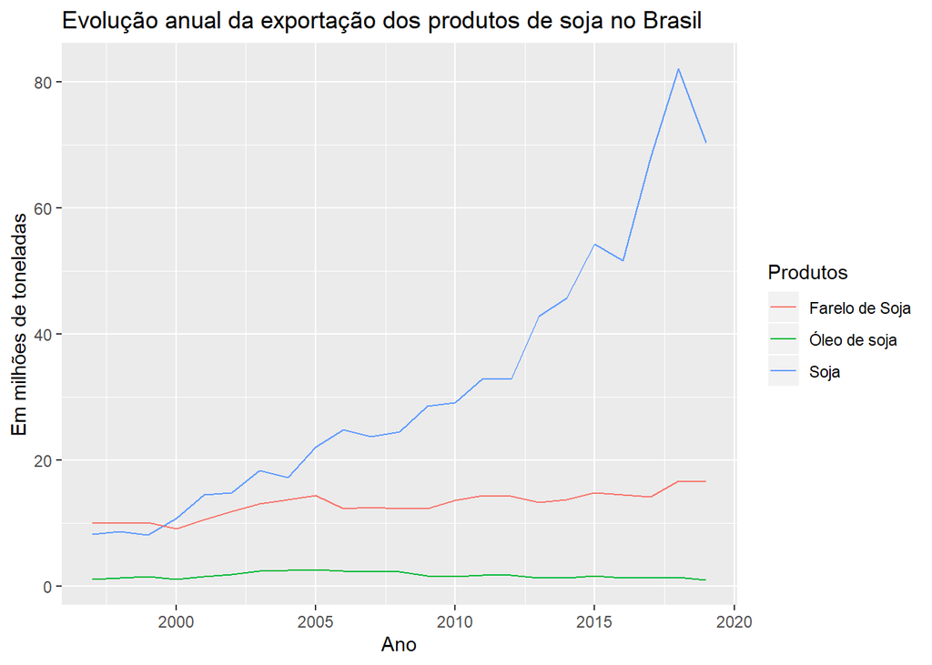

```r
g<-ggplot(dados1) + aes(x = Ano) + geom_line(aes(y = Soybeans_Mtons,col="Soja"))

g + geom_line(aes(y = SoybeansOil_Mtons, col="Óleo de soja")) + geom_line(aes(y = SoybeansMeal_Mtons, col="Farelo de Soja")) +
  labs(title = "Evolução anual da exportação dos produtos de soja no Brasil", x = "Ano", y="Em milhões de toneladas", color = "Produtos")
```

Em uma análise de um período mais recente, podemos ver a evolução mensal desses valores ao longo de 2019, conforme os dados e gráfico a seguir:

```r
# Extraindo os dados da base

soybeans_total_tonsM<-ddply(soybeans_export_tons, c("date"),summarise,soybeans_tons=(sum(tons))/1000000)
soybeansOil_total_tonsM<-ddply(soybeansOil_export_tons, c("date"),summarise,soybeansOil_tons=(sum(tons))/1000000)
soybeansMeal_total_tonsM<-ddply(soybeansMeal_export_tons, c("date"),summarise,soybeansMeal_tons=(sum(tons))/1000000)

dadosM<-data.frame(soybeans_total_tonsM,soybeansOil_total_tonsM$soybeansOil_tons,soybeansMeal_total_tonsM$soybeansMeal_tons)
names(dadosM)[2:4]<-c("Soybeans_Mtons","SoybeansOil_Mtons","SoybeansMeal_Mtons")

dadosMe<-dadosM[grep("2019-",dadosM$date), ]
dadosMe
```

```
##           date Soybeans_Mtons SoybeansOil_Mtons SoybeansMeal_Mtons
## 265 2019-01-01       1.946757        0.04880370           1.236374
## 266 2019-02-01       5.258178        0.04059413           0.899407
## 267 2019-03-01       8.238686        0.08267363           1.409536
## 268 2019-04-01       8.955442        0.07135367           1.431331
## 269 2019-05-01       9.547529        0.20787489           1.593901
## 270 2019-06-01       8.099323        0.14080723           1.606343
## 271 2019-07-01       7.105670        0.12913100           1.472122
## 272 2019-08-01       4.631223        0.10903207           1.348541
## 273 2019-09-01       4.405770        0.07775627           1.350037
## 274 2019-10-01       4.735819        0.06385051           1.393293
## 275 2019-11-01       4.448635        0.02189199           1.171476
## 276 2019-12-01       2.906495        0.03502054           1.618020
```

Mais uma vez, essa evolução é melhor visualizada atravé do gráfico abaixo:

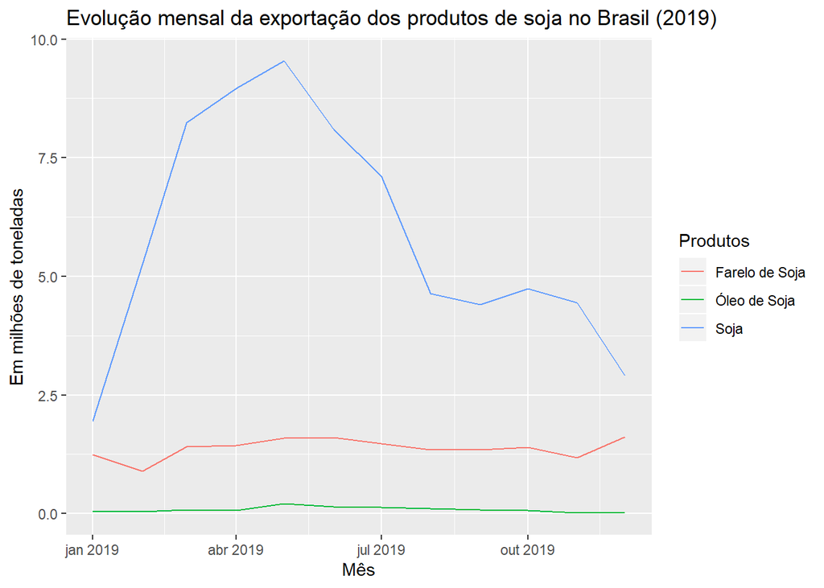

```r
# Gráfico

grafM<-ggplot(dadosMe) + aes(x = as.Date(dadosMe$date)) + geom_line(aes(y = Soybeans_Mtons,col="Soja"))

grafM + geom_line(aes(y = SoybeansOil_Mtons, col="Óleo de Soja")) + geom_line(aes(y = SoybeansMeal_Mtons, col="Farelo de Soja")) +
  labs(title = "Evolução mensal da exportação dos produtos de soja no Brasil (2019)", x = "Mês", y="Em milhões de toneladas", color = "Produtos")
```

## 2) Os três produtos mais importantes da pauta de exportações brasileira nos últimos cinco anos

```r
# Extraindo os dados da base

dados$date<-as.Date(dados$date)
dados["Ano"]<-lubridate::year(dados$date)

dadosExp<-subset(dados, type == "Export") [,c("Ano","product","state","country","route","tons","usd")]
dadosExp_Pr<-ddply(dadosExp, c("Ano","product"),summarise,usd=(sum(tons/1000000)))
dadosExp_Pr<-reshape(dadosExp_Pr, v.names = "usd", idvar = "Ano", timevar="product",direction="wide")
dadosExp_Pr<-dadosExp_Pr[19:23, ]

names(dadosExp_Pr)[2:7]<-c("Corn","Soybeans_Meal","Soybeans_Oil","Soybeans", "Sugar","Wheat")

dadosExp_Pr
```

```
##      Ano     Corn Soybeans_Meal Soybeans_Oil Soybeans    Sugar     Wheat
## 102 2015 28.90038      14.82660     1.669874 54.29562 23.80948 1.7788705
## 108 2016 21.86444      14.44379     1.253542 51.57381 28.80695 0.7133262
## 114 2017 29.25533      14.17674     1.342365 68.00659 28.61423 0.6176644
## 120 2018 22.74727      16.66998     1.414356 82.09939 21.14488 0.2212785
## 126 2019 41.83192      16.53038     1.028790 70.27953 17.65812 0.5546966
```

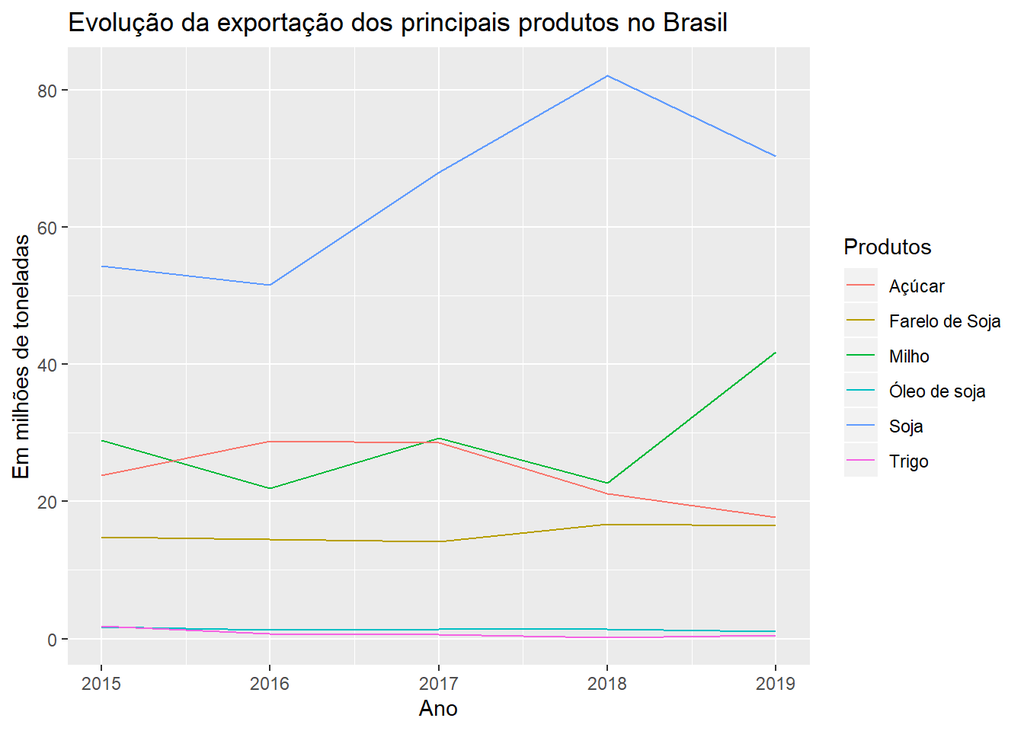

```r
# Gráfico

grafPr<-ggplot(dadosExp_Pr) + aes(x = Ano) + geom_line(aes(y = Corn,col="Milho"))

grafPr + geom_line(aes(y = Soybeans_Meal, col="Farelo de Soja")) + geom_line(aes(y = Soybeans_Oil, col="Óleo de soja")) +
  geom_line(aes(y = Soybeans, col="Soja")) + geom_line(aes(y = Sugar, col="Açúcar")) +
  geom_line(aes(y = Wheat, col="Trigo")) +
  labs(title = "Evolução da exportação dos principais produtos no Brasil", x = "Ano", y="Em milhões de toneladas", color = "Produtos")
```

## 3) Principais rotas para exportações do milho

Em relação ao produto milho, os dados mostram que as rotas mais utilizadas para exportação desta commodity, nos últimos cinco anos, são sea e river. A última coluna da tabela abaixo mostra a parcela da rota mais utilizada (considerando o volume de exportações) em relação ao total exportado por outras fontes em cada ano. Isso quer dizer que, nos últimos cinco anos, a rota com maior representação na exportação do milho, que foi “Sea”, obteve participação maior que 90% em todos os anos.

```r
# Extraindo os dados da base

dadosR<-subset(dadosExp, product == "corn") [ ,c("Ano","state","country","route","tons","usd")]
dadosR<-ddply(dadosR, c("Ano","route"),summarise,tons=(sum(tons/1000000)))
dadosRo<-reshape(dadosR, v.names = "tons", idvar = "Ano", timevar="route",direction="wide")
dadosRou<-dadosRo[19:23, ]
names(dadosRou)[2:6]<-c("Air","Ground","Other","Sea","River")

dadosRou %>% mutate(Total = Air+Ground+Other+River+Sea)  %>%
  mutate(Maior_Participação = pmax(Air,Ground,Other,River,Sea, na.rm = TRUE) / Total)
```

```
##      Ano         Air     Ground       Other      Sea      River    Total
## 82  2015 0.009648313 0.01071715 0.001781068 27.22950 1.64873363 28.90038
## 87  2016 0.000088038 0.01354664 0.001837631 21.12809 0.72087675 21.86444
## 92  2017 0.000236327 0.01159842 0.003407038 27.27977 1.96031357 29.25533
## 97  2018 0.000115876 0.01528226 0.060548490 21.21027 1.46104787 22.74727
## 102 2019 0.000064060 0.02136506 0.198480924 41.53336 0.07865474 41.83192
##     Maior_Participação
## 82           0.9421848
## 87           0.9663221
## 92           0.9324720
## 97           0.9324317
## 102          0.9928628
```

A diferença entre as rotas do milho pode ser melhor vizualizada no gráfico abaixo:

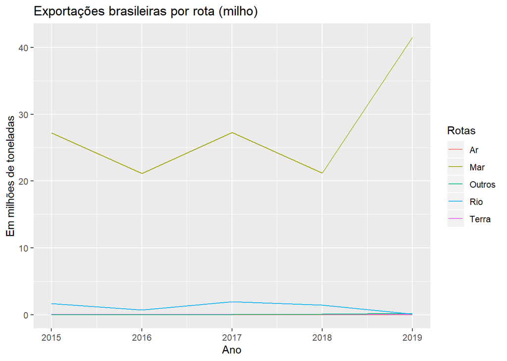

```r
# Gráfico

grafRo<-ggplot(dadosRou) + aes(x = Ano) + geom_line(aes(y = Air,col="Ar"))

grafRo + geom_line(aes(y = Ground, col="Terra")) +
  geom_line(aes(y = Other, col="Outros")) + geom_line(aes(y = River, col="Rio")) +
  geom_line(aes(y = Sea, col="Mar")) +
  labs(title = "Exportações brasileiras por rota (milho)", x = "Ano", y="Em milhões de toneladas", color = "Rotas")
```

Em relação aos demais produtos, os dados extraídos abaixo revelaram que nos últimos 5 anos a rota via mar é a mais utilizada para todos os produtos.

```r
# Extraindo dados da base

library(magrittr)
library(dplyr)
library(tidyr)
dadosA<-ddply(dadosExp, c("Ano","route","product"),summarise,tons=(sum(tons/1000000)))
dadosAl<-dadosA%>%filter(Ano > "2014")
dadosAl<-spread(dadosAl,Ano,tons)
dadosAl<-replace(x = dadosAl, list = is.na(dadosAl), values = 0)
dadosAl
```

```
##     route      product         2015         2016         2017         2018
## 1     Air         corn  0.009648313  0.000088038  0.000236327  0.000115876
## 2     Air soybean_meal  0.000001001  0.022012623  0.000004320  0.000000738
## 3     Air  soybean_oil  0.000000181  0.000000000  0.000000090  0.000000495
## 4     Air     soybeans  0.000006571  0.000027639  0.000007009  0.000006719
## 5     Air        sugar  0.000002902  0.000002019  0.000005379  0.000011149
## 6     Air        wheat  0.000000630  0.000000017  0.000000000  0.000000282
## 7  Ground         corn  0.010717152  0.013546643  0.011598417  0.015282257
## 8  Ground soybean_meal  0.002343670  0.000164480  0.000109680  0.001019308
## 9  Ground  soybean_oil  0.021487157  0.020508009  0.023327094  0.023504984
## 10 Ground     soybeans  0.002890090  0.004534160  0.006993155  0.054459645
## 11 Ground        sugar  0.095761003  0.103893618  0.133496091  0.165782687
## 12 Ground        wheat  0.000161420  0.000471148  0.000110000  0.000157192
## 13  Other         corn  0.001781068  0.001837631  0.003407038  0.060548490
## 14  Other soybean_meal  0.000000000  0.000000000  0.000000000  0.000551425
```

[output cut: 45 more lines]

## 4) Os princiapais parceiros comerciais do Brasil para os produtos milho e açúcar

Os dados consolidados abaixo mostram quais países se destacaram no comércio com o Brasil nos últimos 3 anos em relação aos produtos milho e açúcar.

```r
# Extraindo dados da base - Milho

dadosC<-subset(dados, product == "corn") [,c("Ano","product","state","country","type","route","tons","usd")]
dadosCo<-ddply(dadosC, c("product","Ano","country","type"),summarise,tons=(sum(tons/1000000)))
dadosCor<-dadosCo%>%filter(Ano >"2016")

dadosCorn<-spread(dadosCor,Ano,tons)

dadosCorn<-replace(x = dadosCorn, list = is.na(dadosCorn), values = 0)

dadosCorn<-arrange(dadosCorn,desc(dadosCorn$`2019`))
dadosCorn[1:20, ]
```

```
##    product            country   type        2017       2018      2019
## 1     corn              Japan Export 2.945944364 0.23799957 6.4929772
## 2     corn               Iran Export 4.832977659 6.37903922 5.2136334
## 3     corn            Vietnam Export 2.637304773 2.88891956 3.9207575
## 4     corn        South Korea Export 1.716859900 1.14882465 3.4073837
## 5     corn              Egypt Export 3.224645029 1.90615605 3.2229959
## 6     corn              Spain Export 2.868389223 2.22771598 3.1478362
## 7     corn             Taiwan Export 1.760042654 0.55132372 2.7479970
## 8     corn             Mexico Export 0.562832882 0.13032991 1.8258400
## 9     corn           Malaysia Export 1.494622028 1.19966763 1.5440419
## 10    corn           Paraguay Import 0.774664955 0.70468911 1.3629332
## 11    corn         Bangladesh Export 1.016714801 1.03769902 1.1740217
## 12    corn            Morocco Export 0.484980678 0.56383803 1.0752544
## 13    corn Dominican Republic Export 0.687005257 0.40769212 0.9583188
## 14    corn           Colombia Export 0.002272412 0.00223157 0.8575142
## 15    corn           Portugal Export 0.643711056 0.64914490 0.6573490
## 16    corn       Saudi Arabia Export 0.680764161 0.52649459 0.6035954
## 17    corn            Algeria Export 0.493865690 0.60629658 0.5185232
## 18    corn             Jordan Export 0.163564935 0.27144844 0.4777882
## 19    corn            Ireland Export 0.329079621 0.24715670 0.4575211
## 20    corn        Netherlands Export 0.801673210 0.51910409 0.4371040
```

De acordo com os dados, considerando os 20 países com maior volume de negócios com o Brasil, o milho tem a maioria do comércio internacional referente à vendas externas. Ordenando pelo ano mais recente (2019), 6,5 milhôes de toneladas de milho foram exportadas para o Japão, seguido do Iran, Vietnam e Coréia so Sul. Em relação as compras nacionais do produto, o Paraguai aparece em destaque no ano de 2019 com 1,4 milhôes de toneladas em importação.

```r
# Extraindo dados da base - Açúcar

dadosAc<-subset(dados, product == "sugar") [,c("Ano","product","state","country","type","route","tons","usd")]
dadosAc<-ddply(dadosAc, c("product","Ano","country","type"),summarise,tons=(sum(tons/1000000)))
dadosAc<-dadosAc%>%filter(Ano >"2016")
dadosAc<-spread(dadosAc,Ano,tons)
dadosAc<-replace(x = dadosAc, list = is.na(dadosAc), values = 0)

dadosAc<-arrange(dadosAc,desc(dadosAc$`2019`))
dadosAc[1:20, ]
```

```
##    product              country   type      2017      2018      2019
## 1    sugar              Algeria Export 2.2151931 2.2749858 2.2066753
## 2    sugar           Bangladesh Export 2.8372841 1.7590799 1.7352761
## 3    sugar              Nigeria Export 1.3677843 1.2904561 1.4985737
## 4    sugar         Saudi Arabia Export 1.3961304 1.3957364 1.4575951
## 5    sugar                China Export 0.3339283 0.7897788 1.4031569
## 6    sugar                 Iraq Export 1.4595390 1.1298657 0.9658365
## 7    sugar                India Export 2.4170972 1.8591052 0.8351695
## 8    sugar              Morocco Export 1.1385519 0.9658727 0.7464683
## 9    sugar United Arab Emirates Export 2.2833472 1.5827069 0.6797480
## 10   sugar                Egypt Export 1.5741686 0.8308411 0.6662141
## 11   sugar                 Iran Export 0.7258020 0.1185000 0.5877830
## 12   sugar                Yemen Export 0.7565949 0.4365393 0.5443804
## 13   sugar               Canada Export 0.9655254 0.9735083 0.5229560
## 14   sugar               Angola Export 0.4177430 0.3124777 0.4161755
## 15   sugar        United States Export 0.3185710 0.2959732 0.3104365
## 16   sugar               Russia Export 0.4935708 0.2344024 0.3081120
## 17   sugar             Malaysia Export 1.6842107 1.0035435 0.2939750
## 18   sugar                Benin Export 0.2569655 0.4025735 0.2295543
## 19   sugar              Tunisia Export 0.4040989 0.4244953 0.1992500
## 20   sugar                 Togo Export 0.1933709 0.2253568 0.1387491
```

Entre os 20 países que mais compraram o açúcar brasileiro em 2019 e em milhões de toneladas, destacaram-se os países: Argélia, Bangladesh, Nigéria e Arábia Saudita.

## 5) Os estados mais importantes nas exportações brasileiras para cada produto da base

```r
# Extraindo dados da base para cada produto

# Corn
dadosExp_Corn<-subset(dados, product == "corn" & type == "Export") [,c("Ano","product","state","country","type","route","tons","usd")]
dadosExp_Corn<-ddply(dadosExp_Corn, c("Ano","product","state"),summarise,tons=(sum(tons/1000000)))
dadosExp_Corn<-dadosExp_Corn%>%filter(Ano >"2014")
dadosExp_Corn<-spread(dadosExp_Corn,Ano,tons)
dadosExp_Corn<-replace(x = dadosExp_Corn, list = is.na(dadosExp_Corn), values = 0)

dadosExp_Corn<-dadosExp_Corn %>% mutate(Soma = (`2015`+`2016`+`2017`+`2018`+`2019`))  %>%
    mutate(Média = Soma/ 5)

dadosExp_Corn<-arrange(dadosExp_Corn,desc(dadosExp_Corn$Média))
dadosExp_Corn[1:5, ]
```

```
##   product state      2015       2016       2017      2018      2019      Soma
## 1    corn    MT 14.457836 14.3178552 18.2729735 17.691899 24.882263 89.622827
## 2    corn    GO  3.724297  2.2375075  3.1431881  1.718512  5.043464 15.866969
## 3    corn    PR  3.637307  1.8427972  2.9759444  1.119165  4.701022 14.276236
## 4    corn    MS  2.869184  1.8850663  2.1821803  0.593926  2.655525 10.185882
## 5    corn    SP  1.492317  0.7113971  0.9070935  0.397403  1.180595  4.688806
##        Média
## 1 17.9245654
## 2  3.1733938
## 3  2.8552473
## 4  2.0371764
## 5  0.9377612
```

Os dados acima estão ordenados pela coluna “Média”, ela mostra a média do volume exportado nos últimos 5 anos para cada estado. No caso do milho, os 5 estados que mais exportaram foram: Mato Grosso, Goiás, Paraná, Mato Grosso do Sul e São Paulo. O mesmo mecanismo foi aplicado na extração de dados de todos os produtos.

```r
# soybean_meal
dadosExp_SoyM<-subset(dados, product == "soybean_meal" & type == "Export") [,c("Ano","product","state","country","type","route","tons","usd")]
dadosExp_SoyM<-ddply(dadosExp_SoyM, c("Ano","product","state"),summarise,tons=(sum(tons/1000000)))
dadosExp_SoyM<-dadosExp_SoyM%>%filter(Ano >"2014")
dadosExp_SoyM<-spread(dadosExp_SoyM,Ano,tons)
dadosExp_SoyM<-replace(x = dadosExp_SoyM, list = is.na(dadosExp_SoyM), values = 0)

dadosExp_SoyM<-dadosExp_SoyM %>% mutate(Soma = (`2015`+`2016`+`2017`+`2018`+`2019`))  %>%
  mutate(Média = Soma/ 5)

dadosExp_SoyM<-arrange(dadosExp_SoyM,desc(dadosExp_SoyM$Média))
dadosExp_SoyM[1:5, ]
```

```
##        product state     2015     2016      2017     2018     2019      Soma
## 1 soybean_meal    MT 4.955616 4.891086 5.2200969 5.786309 5.248513 26.101621
## 2 soybean_meal    PR 3.297871 3.369058 3.2112377 3.256434 3.450703 16.585303
## 3 soybean_meal    RS 2.692430 2.511168 2.0485317 2.633324 2.440466 12.325919
## 4 soybean_meal    GO 1.305324 1.531653 2.0543078 2.160875 2.136121  9.188281
## 5 soybean_meal    BA 0.989490 1.020307 0.9456379 1.182268 1.032665  5.170368
##      Média
## 1 5.220324
## 2 3.317061
## 3 2.465184
## 4 1.837656
## 5 1.034074
```

Para o farelo de soja, os estados Mato Grosso e Paraná lideram a lista, seguido do Rio Grande do Sul, Goías e Bahia.

```r
# soybean_oil
dadosExp_SoyO<-subset(dados, product == "soybean_oil" & type == "Export") [,c("Ano","product","state","country","type","route","tons","usd")]
dadosExp_SoyO<-ddply(dadosExp_SoyO, c("Ano","product","state"),summarise,tons=(sum(tons/1000000)))
dadosExp_SoyO<-dadosExp_SoyO%>%filter(Ano >"2014")
dadosExp_SoyO<-spread(dadosExp_SoyO,Ano,tons)
dadosExp_SoyO<-replace(x = dadosExp_SoyO, list = is.na(dadosExp_SoyO), values = 0)

dadosExp_SoyO<-dadosExp_SoyO %>% mutate(Soma = (`2015`+`2016`+`2017`+`2018`+`2019`))  %>%
  mutate(Média = Soma/ 5)

dadosExp_SoyO<-arrange(dadosExp_SoyO,desc(dadosExp_SoyO$Média))
dadosExp_SoyO[1:5, ]
```

```
##       product state       2015       2016       2017       2018       2019
## 1 soybean_oil    PR 0.75832794 0.53778730 0.57443262 0.56160118 0.37757816
## 2 soybean_oil    MT 0.37744336 0.19515623 0.24215881 0.28910527 0.26517365
## 3 soybean_oil    RS 0.31702838 0.28577126 0.28239811 0.24528281 0.11908281
## 4 soybean_oil    GO 0.10245610 0.17062352 0.17731232 0.20291745 0.13665147
## 5 soybean_oil    SC 0.06283441 0.02717859 0.03935391 0.07501924 0.04096692
##        Soma      Média
## 1 2.8097272 0.56194544
## 2 1.3690373 0.27380746
## 3 1.2495634 0.24991267
## 4 0.7899609 0.15799217
## 5 0.2453531 0.04907061
```

O óleo de soja é mais exportado pelo Paraná, seguido pelo Mato Grosso, Rio Grande do Sul, Goiás e Santa Catarina.

```r
# soybeans
dadosExp_Soy<-subset(dados, product == "soybeans" & type == "Export") [,c("Ano","product","state","country","type","route","tons","usd")]
dadosExp_Soy<-ddply(dadosExp_Soy, c("Ano","product","state"),summarise,tons=(sum(tons/1000000)))
dadosExp_Soy<-dadosExp_Soy%>%filter(Ano >"2014")
dadosExp_Soy<-spread(dadosExp_Soy,Ano,tons)
dadosExp_Soy<-replace(x = dadosExp_Soy, list = is.na(dadosExp_Soy), values = 0)

dadosExp_Soy<-dadosExp_Soy %>% mutate(Soma = (`2015`+`2016`+`2017`+`2018`+`2019`))  %>%
  mutate(Média = Soma/ 5)

dadosExp_Soy<-arrange(dadosExp_Soy,desc(dadosExp_Soy$Média))
dadosExp_Soy[1:5, ]
```

```
##    product state      2015      2016      2017      2018      2019     Soma
## 1 soybeans    MT 14.514829 15.222273 18.017494 19.954206 20.228382 87.93718
## 2 soybeans    RS 10.654789  9.529690 12.349354 13.246519 11.609923 57.39027
## 3 soybeans    PR  7.779706  7.972653 10.927870 12.983852  9.617767 49.28185
## 4 soybeans    GO  3.225232  3.549453  4.805430  6.187001  4.696491 22.46361
## 5 soybeans    MS  3.447470  2.892712  3.642179  5.198305  3.275056 18.45572
##       Média
## 1 17.587436
## 2 11.478055
## 3  9.856370
## 4  4.492721
## 5  3.691144
```

Já a soja tem os estados do Mato Grosso, Rio Grande do Sul, Paraná, Goías e Mato Grosso do Sul, como principais fontes de exportação.

```r
# Wheat
dadosExp_Wh<-subset(dados, product == "wheat" & type == "Export") [,c("Ano","product","state","country","type","route","tons","usd")]
dadosExp_Wh<-ddply(dadosExp_Wh, c("Ano","product","state"),summarise,tons=(sum(tons/1000000)))
dadosExp_Wh<-dadosExp_Wh%>%filter(Ano >"2014")
dadosExp_Wh<-spread(dadosExp_Wh,Ano,tons)
dadosExp_Wh<-replace(x = dadosExp_Wh, list = is.na(dadosExp_Wh), values = 0)

dadosExp_Wh<-dadosExp_Wh %>% mutate(Soma = (`2015`+`2016`+`2017`+`2018`+`2019`))  %>%
  mutate(Média = Soma/ 5)

dadosExp_Wh<-arrange(dadosExp_Wh,desc(dadosExp_Wh$Média))
dadosExp_Wh[1:5, ]
```

```
##   product state        2015       2016        2017        2018        2019
## 1   wheat    RS 1.586684220 0.55718288 0.617559203 0.221248437 0.545269773
## 2   wheat    PR 0.173985169 0.15613802 0.000062313 0.000027329 0.009358528
## 3   wheat    SP 0.009983412 0.00000083 0.000000920 0.000001078 0.000062987
## 4   wheat    SC 0.008003000 0.00000200 0.000003000 0.000001000 0.000002000
## 5   wheat    MG 0.000210428 0.00000045 0.000000000 0.000000000 0.000000000
##          Soma        Média
## 1 3.527944517 0.7055889034
## 2 0.339571359 0.0679142718
## 3 0.010049227 0.0020098454
## 4 0.008011000 0.0016022000
## 5 0.000210878 0.0000421756
```

De acorso com os dados, o trigo, em termos de volume, é menos exportado em relação aos outros produtos. Os estados que mais exportam essa commodity são: Rio Grande do Sul, Paraná, São Paulo, Santa Catarina e Minas Gerais.

```r
# sugar
dadosExp_Su<-subset(dados, product == "sugar" & type == "Export") [,c("Ano","product","state","country","type","route","tons","usd")]
dadosExp_Su<-ddply(dadosExp_Su, c("Ano","product","state"),summarise,tons=(sum(tons/1000000)))
dadosExp_Su<-dadosExp_Su%>%filter(Ano >"2014")
dadosExp_Su<-spread(dadosExp_Su,Ano,tons)
dadosExp_Su<-replace(x = dadosExp_Su, list = is.na(dadosExp_Su), values = 0)

dadosExp_Su<-dadosExp_Su %>% mutate(Soma = (`2015`+`2016`+`2017`+`2018`+`2019`))  %>%
  mutate(Média = Soma/ 5)

dadosExp_Su<-arrange(dadosExp_Su,desc(dadosExp_Su$Média))
dadosExp_Su[1:5, ]
```

```
##   product state      2015      2016      2017       2018       2019      Soma
## 1   sugar    SP 14.817122 19.110997 19.004805 13.8964200 11.1141315 77.943475
## 2   sugar    MG  2.553266  3.211115  3.219506  2.4900949  2.2707993 13.744782
## 3   sugar    PR  2.584362  2.832908  2.676257  2.2538919  2.0349683 12.382387
## 4   sugar    AL  1.411498  1.009080  1.033082  0.9290521  0.9256600  5.308372
## 5   sugar    MS  1.097460  1.263233  1.378331  0.4683536  0.2388103  4.446188
##        Média
## 1 15.5886950
## 2  2.7489563
## 3  2.4764774
## 4  1.0616743
## 5  0.8892375
```

Por fim, o açúcar é mais comercializado internacionalmente pelos estados de São Paulo, Minas Gerais, Paraná, Alagoas e Mato Grosso do Sul.

## 6) Projeção anual para os produtos soja, farelo de soja e milho, em toneladas, para os próximos 11 anos (2020-2030)

```r
# Extraindo os dados das variáveis do modelo

## Exportações

# soybeans
dadosExp_Soyf<-subset(dados, product == "soybeans" & type == "Export") [,c("Ano","product","state","country","type","route","tons","usd")]
dadosExp_Soyf<-ddply(dadosExp_Soyf, c("Ano"),summarise,tons=(sum(tons/1000000)))
Exp_Soy<-ts(dadosExp_Soyf$tons, start = 1997,frequency = 1)

# soybean_meal
dadosExp_SoyMf<-subset(dados, product == "soybean_meal" & type == "Export") [,c("Ano","product","state","country","type","route","tons","usd")]
dadosExp_SoyMf<-ddply(dadosExp_SoyMf, c("Ano"),summarise,tons=(sum(tons/1000000)))
Exp_SoyMf<-ts(dadosExp_SoyMf$tons, start = 1997, frequency = 1)

#Corn
dadosExp_Cornf<-subset(dados, product == "corn" & type == "Export") [,c("Ano","product","state","country","type","route","tons","usd")]
dadosExp_Cornf<-ddply(dadosExp_Cornf, c("Ano"),summarise,tons=(sum(tons/1000000)))
Exp_Corn<-ts(dadosExp_Cornf$tons, start = 1997, frequency = 1)

# Covariáveis

base1<-readxl::read_xlsx("covariates.xlsx")
```

```
## * Soja -> Soja...14
## * Soja -> Soja...15
## * `` -> ...16
```

```r
write.csv2(base1,"C:/Users/regia/OneDrive/Documents/Regiane/CV/4Intelligence/Exercicio/base.csv")
base<-read.csv2("base.csv")

# GDP
GDP_China<-base[19:41,c("gdp_china")]
GDP_China<-ts(GDP_China, start = 1997, frequency = 1)

GDP_Spain<-base[19:41,c("gdp_spain")]
GDP_Spain<-ts(GDP_Spain, start = 1997, frequency = 1)

GDP_Thailand<-base[19:41,c("gdp_thailand")]
GDP_Thailand<-ts(GDP_Thailand, start = 1997)

GDP_Netherlands<-base[19:41,c("gpd_netherlands")]
GDP_Netherlands<-ts(GDP_Netherlands,start = 1997, frequency = 1)

GDP_Iran<-base[19:41,c("gdp_iran")]
GDP_Iran<-ts(GDP_Iran, start = 1997, frequency = 1)

GDP_World<-base[19:41,c("gdp_world")]
GDP_World<-ts(GDP_World, start = 1997, frequency = 1)

GDP_Vietnam<-base[19:41,c("gdp_vietnam")]
GDP_Vietnam<-ts(GDP_Vietnam, start = 1997, frequency = 1)

GDP_Japan<-base[19:41,c("gdp_japan")]
GDP_Japan<-ts(GDP_Japan, start = 1997, frequency = 1)

GDP_Egypt<-base[19:41,c("gdp_egypt")]
GDP_Egypt<-ts(GDP_Egypt, start = 1997, frequency = 1)

# Preço
PSoy<-base[19:41,c("price_soybeans")]
PSoy<-ts(PSoy, start = 1997, frequency = 1)

PSoyM<-base[19:41,c("price_soybean_meal")]
PSoyM<-ts(PSoyM, start = 1997, frequency = 1)

PCorn<-base[19:41,c("price_corn")]
PCorn<-ts(PCorn, start = 1997,frequency = 1)
```

Os principais compradores dos produtos soja, farelo de soja e milho estão nos dados abaixo

```r
# Extraindo dados da base

# Soja
dadosExp_SoyC<-subset(dados, product == "soybeans" & type == "Export") [,c("Ano","product","state","country","type","route","tons","usd")]
dadosExp_SoyC<-ddply(dadosExp_SoyC, c("Ano","product","country"),summarise,tons=(sum(tons/1000000)))
dadosExp_SoyC<-dadosExp_SoyC%>%filter(Ano >"2014")
dadosExp_SoyC<-spread(dadosExp_SoyC,Ano,tons)
dadosExp_SoyC<-replace(x = dadosExp_SoyC, list = is.na(dadosExp_SoyC), values = 0)

dadosExp_SoyC<-dadosExp_SoyC %>% mutate(Soma = (`2015`+`2016`+`2017`+`2018`+`2019`))  %>%
  mutate(Média = Soma/ 5)

dadosExp_SoyC<-arrange(dadosExp_SoyC,desc(dadosExp_SoyC$Média))
dadosExp_SoyC[1:5, ]
```

```
##    product     country       2015      2016      2017      2018      2019
## 1 soybeans       China 40.9255070 38.563909 53.733447 67.547214 54.411695
## 2 soybeans       Spain  2.3762573  1.621691  2.016854  1.889039  2.182823
## 3 soybeans    Thailand  1.7337292  1.531616  1.652846  1.193827  1.653242
## 4 soybeans Netherlands  1.4960722  1.490261  1.517004  1.305698  1.622188
## 5 soybeans        Iran  0.5515918  1.182706  1.247109  1.297634  1.525907
##         Soma     Média
## 1 255.181772 51.036354
## 2  10.086665  2.017333
## 3   7.765260  1.553052
## 4   7.431224  1.486245
## 5   5.804947  1.160989
```

```r
# Farelo de Soja
dadosExp_SoyMC<-subset(dados, product == "soybean_meal" & type == "Export") [,c("Ano","product","state","country","type","route","tons","usd")]
dadosExp_SoyMC<-ddply(dadosExp_SoyMC, c("Ano","product","country"),summarise,tons=(sum(tons/1000000)))
dadosExp_SoyMC<-dadosExp_SoyMC%>%filter(Ano >"2014")
dadosExp_SoyMC<-spread(dadosExp_SoyMC,Ano,tons)
dadosExp_SoyMC<-replace(x = dadosExp_SoyMC, list = is.na(dadosExp_SoyMC), values = 0)

dadosExp_SoyMC<-dadosExp_SoyMC %>% mutate(Soma = (`2015`+`2016`+`2017`+`2018`+`2019`))  %>%
  mutate(Média = Soma/ 5)

dadosExp_SoyMC<-arrange(dadosExp_SoyMC,desc(dadosExp_SoyMC$Média))
dadosExp_SoyMC[1:5, ]
```

```
##        product     country     2015     2016     2017     2018     2019
## 1 soybean_meal Netherlands 3.120910 2.817178 2.638182 2.639166 2.392670
## 2 soybean_meal    Thailand 1.167396 1.536904 1.894529 2.391441 1.901227
## 3 soybean_meal      France 1.703572 1.801979 1.567483 1.523603 1.732493
## 4 soybean_meal   Indonesia 1.994757 1.437994 1.476813 1.653299 1.513740
## 5 soybean_meal South Korea 1.083343 1.479641 1.610532 1.778764 1.503393
##        Soma    Média
## 1 13.608106 2.721621
## 2  8.891496 1.778299
## 3  8.329131 1.665826
## 4  8.076603 1.615321
## 5  7.455673 1.491135
```

```r
# Milho
dadosExp_CornC<-subset(dados, product == "corn" & type == "Export") [,c("Ano","product","state","country","type","route","tons","usd")]
dadosExp_CornC<-ddply(dadosExp_CornC, c("Ano","product","country"),summarise,tons=(sum(tons/1000000)))
dadosExp_CornC<-dadosExp_CornC%>%filter(Ano >"2014")
dadosExp_CornC<-spread(dadosExp_CornC,Ano,tons)
dadosExp_CornC<-replace(x = dadosExp_CornC, list = is.na(dadosExp_CornC), values = 0)

dadosExp_CornC<-dadosExp_CornC %>% mutate(Soma = (`2015`+`2016`+`2017`+`2018`+`2019`))  %>%
  mutate(Média = Soma/ 5)

dadosExp_CornC<-arrange(dadosExp_CornC,desc(dadosExp_CornC$Média))
dadosExp_CornC[1:5, ]
```

```
##   product     country     2015     2016     2017      2018     2019     Soma
## 1    corn        Iran 4.207984 4.790788 4.832978 6.3790392 5.213633 25.42442
## 2    corn     Vietnam 4.831224 2.877048 2.637305 2.8889196 3.920757 17.15525
## 3    corn       Japan 2.776861 2.694266 2.945944 0.2379996 6.492977 15.14805
## 4    corn       Egypt 2.002298 1.498015 3.224645 1.9061560 3.222996 11.85411
## 5    corn South Korea 3.004043 1.482723 1.716860 1.1488247 3.407384 10.75983
##      Média
## 1 5.084884
## 2 3.431051
## 3 3.029610
## 4 2.370822
## 5 2.151967
```

Visualização dos dados:

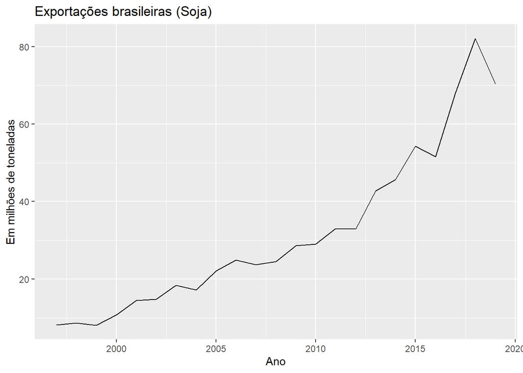

```r
# Soja
graf<-ggplot(dadosExp_Soyf) + aes(x = Ano) + geom_line(aes(y = tons)) + labs(title = "Exportações brasileiras (Soja)", x = "Ano", y="Em milhões de toneladas")
graf
```

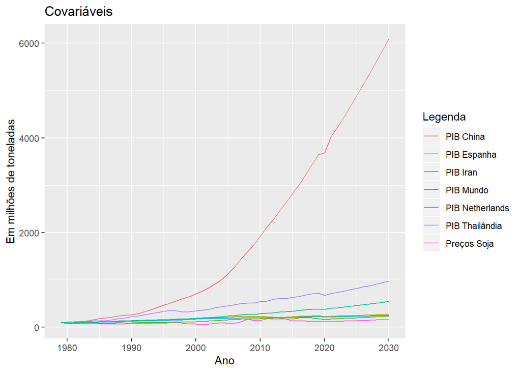

```r
gra<-ggplot(base) + aes(x = year) + geom_line(aes(y = price_soybeans,col="Preços Soja"))

gra +  geom_line(aes(y = gdp_china, col="PIB China")) + geom_line(aes(y = gdp_spain, col="PIB Espanha")) +
  geom_line(aes(y = gdp_thailand, col="PIB Thailândia")) + geom_line(aes(y = gpd_netherlands, col="PIB Netherlands"))+
  geom_line(aes(y = gdp_iran, col="PIB Iran")) + geom_line(aes(y = gdp_world, col="PIB Mundo")) +
  labs(title = "Covariáveis", x = "Ano", y="Em milhões de toneladas", color = "Legenda")
```

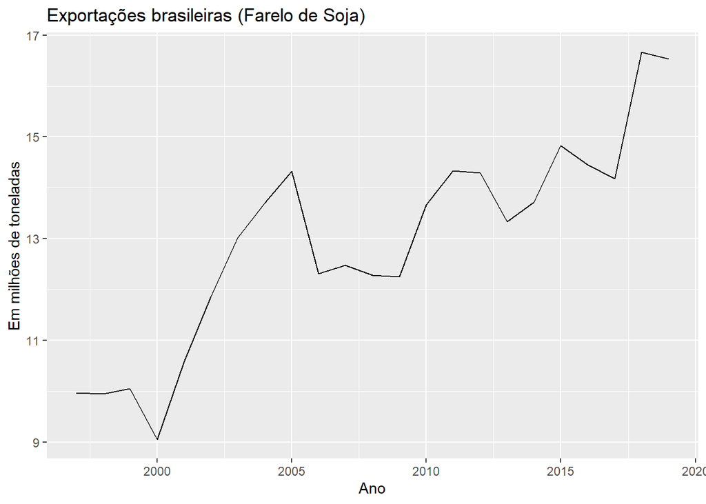

```r
## Farelo de soja

graf_ExpSoyM<-ggplot(dadosExp_SoyMf) + aes(x = Ano) + geom_line(aes(y = tons)) + labs(title = "Exportações brasileiras (Farelo de Soja)", x = "Ano", y="Em milhões de toneladas")
graf_ExpSoyM
```

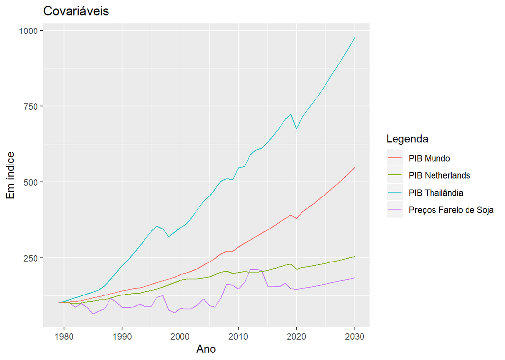

```r
graf_PSoyM<-ggplot(base) + aes(x = year) + geom_line(aes(y = price_soybean_meal,col="Preços Farelo de Soja"))

graf_PSoyM +  geom_line(aes(y = gdp_thailand, col="PIB Thailândia")) + geom_line(aes(y = gpd_netherlands, col="PIB Netherlands")) + geom_line(aes(y = gdp_world, col="PIB Mundo")) +
  labs(title = "Covariáveis", x = "Ano", y="Em índice", color = "Legenda")
```

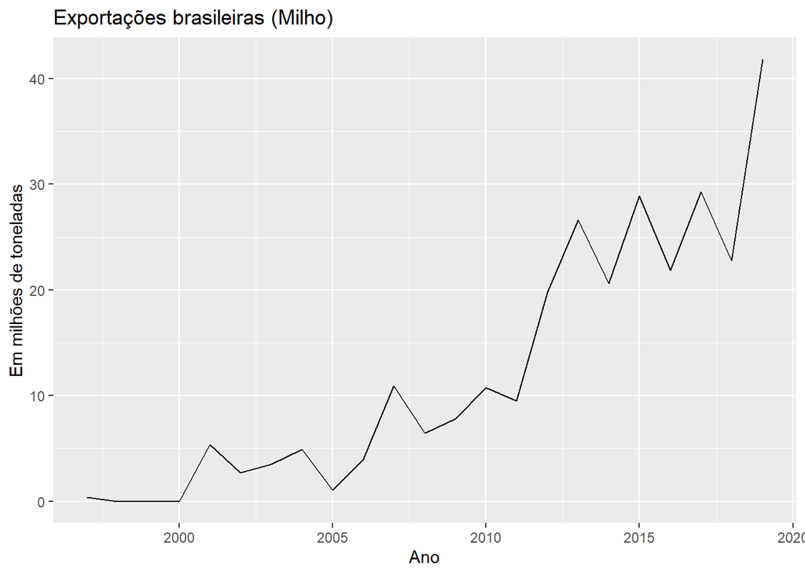

```r
# Milho

graf_ExpCorn<-ggplot(dadosExp_Cornf) + aes(x = Ano) + geom_line(aes(y = tons)) + labs(title = "Exportações brasileiras (Milho)", x = "Ano", y="Em milhões de toneladas")
graf_ExpCorn
```

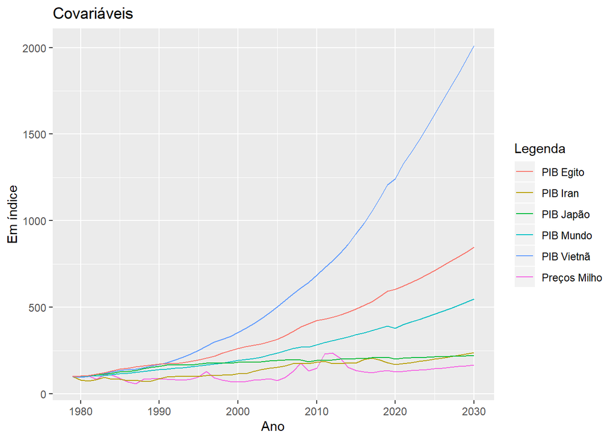

```r
graf_PrCorn<-ggplot(base) + aes(x = year) + geom_line(aes(y = price_corn,col="Preços Milho"))

graf_PrCorn + geom_line(aes(y = gdp_iran, col="PIB Iran")) + geom_line(aes(y = gdp_vietnam, col="PIB Vietnã")) +
  geom_line(aes(y = gdp_world, col="PIB Mundo")) + geom_line(aes(y = gdp_japan, col="PIB Japão")) +
  geom_line(aes(y = gdp_egypt, col="PIB Egito")) +
  labs(title = "Covariáveis", x = "Ano", y="Em índice", color = "Legenda")
```

Considerando os gráficos das séries temporais das variáveis envolvidas, que parecem mover-se de forma semelhantes ao longo do tempo, optou-se pelo modelo de Vetores Autorregressivos (VAR). Dessa forma, os próximos passos seguem abaixo, inciando com a análise da estacionariedade das séries para a projeção de cada produto.

```r
### Projeção
## Soja
# Estacionariedade

# Exportações
adfSoy<-adf.test(Exp_Soy)
adfSoy
```

```
##
##  Augmented Dickey-Fuller Test
##
## data:  Exp_Soy
## Dickey-Fuller = 1.4722, Lag order = 2, p-value = 0.99
## alternative hypothesis: stationary
```

```r
adf.test(diff(diff(Exp_Soy)))
```

```
##
##  Augmented Dickey-Fuller Test
##
## data:  diff(diff(Exp_Soy))
## Dickey-Fuller = -5.8159, Lag order = 2, p-value = 0.01
## alternative hypothesis: stationary
```

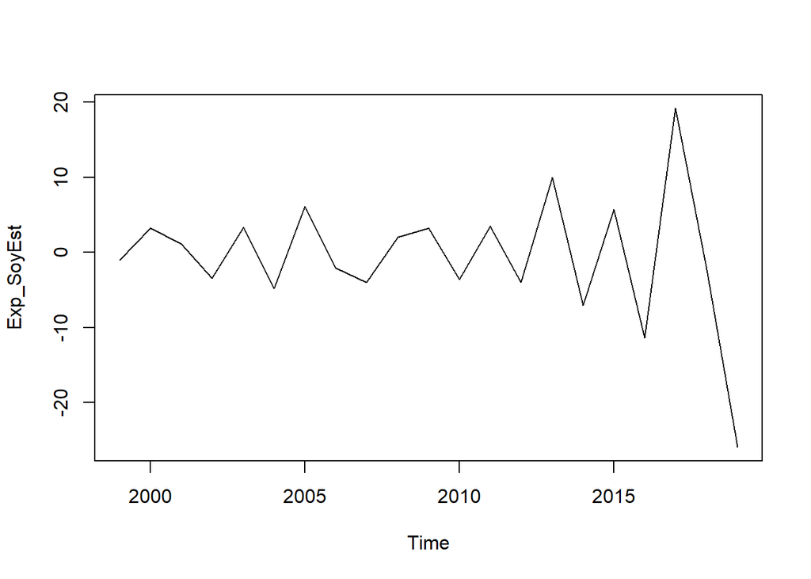

```r
Exp_SoyEst<-diff(diff(Exp_Soy))

plot(Exp_SoyEst,type = "l")
```

```r
# Preço
adfPr<-adf.test(PSoy)
adfPr
```

```
##
##  Augmented Dickey-Fuller Test
##
## data:  PSoy
## Dickey-Fuller = -0.77962, Lag order = 2, p-value = 0.9517
## alternative hypothesis: stationary
```

```r
adf.test(diff(diff(PSoy)))
```

```
##
##  Augmented Dickey-Fuller Test
##
## data:  diff(diff(PSoy))
## Dickey-Fuller = -4.7014, Lag order = 2, p-value = 0.01
## alternative hypothesis: stationary
```

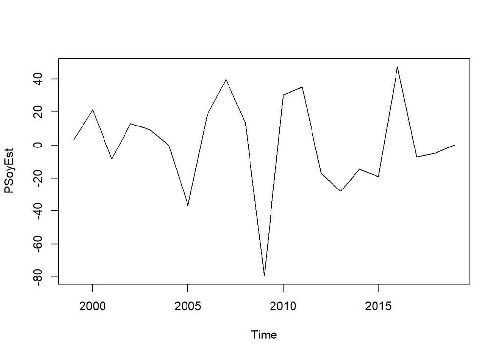

```r
PSoyEst<-diff(diff(PSoy))
plot(PSoyEst, type = "l")
```

```r
# PIB China

adfGDPCh<-adf.test(GDP_China)
adfGDPCh
```

```
##
##  Augmented Dickey-Fuller Test
##
## data:  GDP_China
## Dickey-Fuller = -2.9943, Lag order = 2, p-value = 0.1936
## alternative hypothesis: stationary
```

```r
adf.test(diff(diff(diff(GDP_China))))
```

```
##
##  Augmented Dickey-Fuller Test
##
## data:  diff(diff(diff(GDP_China)))
## Dickey-Fuller = -4.6725, Lag order = 2, p-value = 0.01
## alternative hypothesis: stationary
```

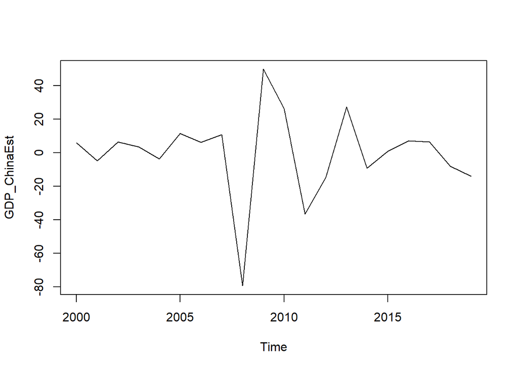

```r
GDP_ChinaEst<-diff(diff(diff(GDP_China)))
plot(GDP_ChinaEst, type="l")
```

```r
# GDP_Spain

adfGDPSpa<-adf.test(GDP_Spain)
adfGDPSpa
```

```
##
##  Augmented Dickey-Fuller Test
##
## data:  GDP_Spain
## Dickey-Fuller = -2.2728, Lag order = 2, p-value = 0.4685
## alternative hypothesis: stationary
```

```r
adf.test(diff(diff(GDP_Spain)))
```

```
##
##  Augmented Dickey-Fuller Test
##
## data:  diff(diff(GDP_Spain))
## Dickey-Fuller = -2.5219, Lag order = 2, p-value = 0.3736
## alternative hypothesis: stationary
```

```r
adf.test(diff(diff(diff(GDP_Spain))))
```

```
##
##  Augmented Dickey-Fuller Test
##
## data:  diff(diff(diff(GDP_Spain)))
## Dickey-Fuller = -3.8944, Lag order = 2, p-value = 0.02897
## alternative hypothesis: stationary
```

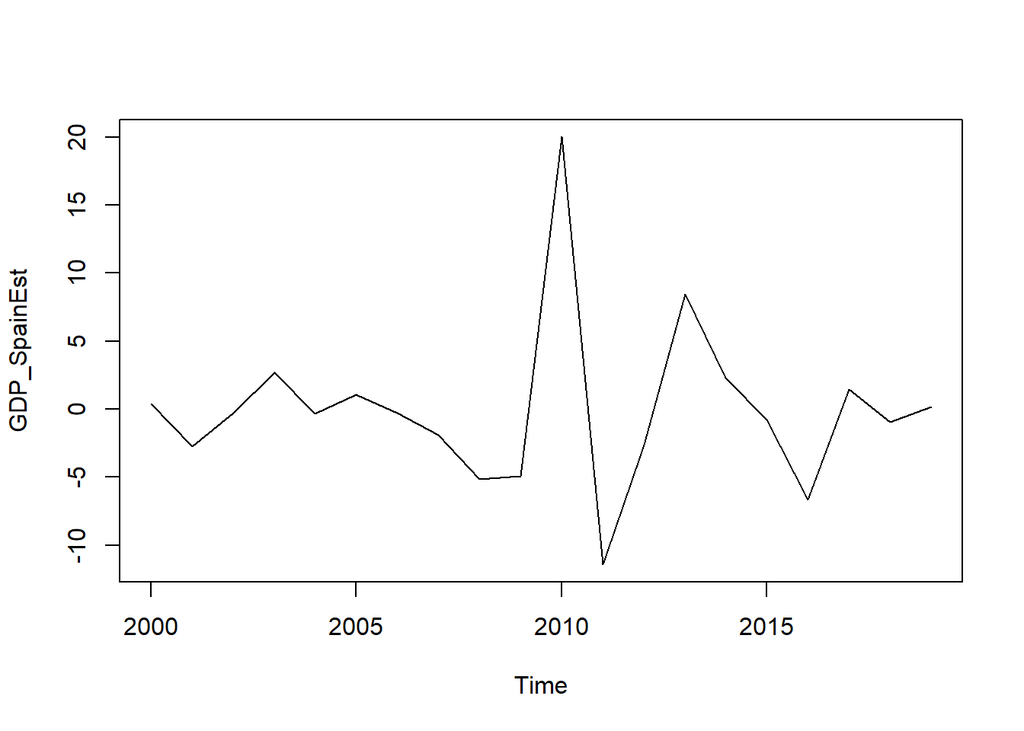

```r
GDP_SpainEst<-diff(diff(diff(GDP_Spain)))
plot(GDP_SpainEst,type="l")
```

```r
# GDP_Thailand

adfGDPThai<-adf.test(GDP_Thailand)
adfGDPThai
```

```
##
##  Augmented Dickey-Fuller Test
##
## data:  GDP_Thailand
## Dickey-Fuller = -2.6882, Lag order = 2, p-value = 0.3102
## alternative hypothesis: stationary
```

```r
adf.test(diff(diff(diff(GDP_Thailand))))
```

```
##
##  Augmented Dickey-Fuller Test
##
## data:  diff(diff(diff(GDP_Thailand)))
## Dickey-Fuller = -4.2516, Lag order = 2, p-value = 0.01448
## alternative hypothesis: stationary
```

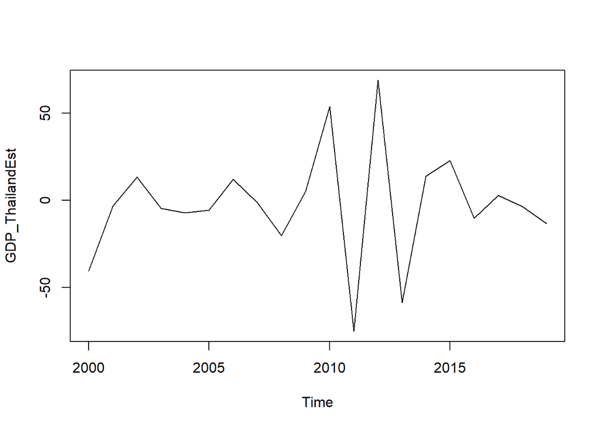

```r
GDP_ThailandEst<-diff(diff(diff(GDP_Thailand)))
plot(GDP_ThailandEst,type="l")
```

```r
# GDP_Netherlands

adfGDPNe<-adf.test(GDP_Netherlands)
adfGDPNe
```

```
##
##  Augmented Dickey-Fuller Test
##
## data:  GDP_Netherlands
## Dickey-Fuller = -2.2081, Lag order = 2, p-value = 0.4931
## alternative hypothesis: stationary
```

```r
adf.test(diff(diff(diff(GDP_Netherlands))))
```

```
##
##  Augmented Dickey-Fuller Test
##
## data:  diff(diff(diff(GDP_Netherlands)))
## Dickey-Fuller = -4.5904, Lag order = 2, p-value = 0.01
## alternative hypothesis: stationary
```

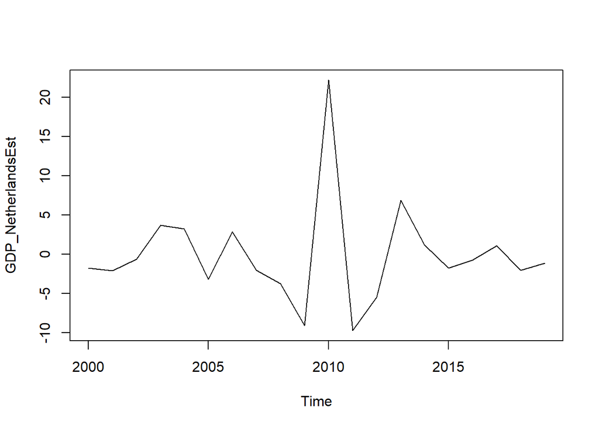

```r
GDP_NetherlandsEst<-diff(diff(diff(GDP_Netherlands)))
plot(GDP_NetherlandsEst,type="l")
```

```r
# GDP_Iran
adfGDPIr<-adf.test(GDP_Iran)
adfGDPIr
```

```
##
##  Augmented Dickey-Fuller Test
##
## data:  GDP_Iran
## Dickey-Fuller = -0.90584, Lag order = 2, p-value = 0.9344
## alternative hypothesis: stationary
```

```r
adf.test(diff(diff(diff(GDP_Iran))))
```

```
##
##  Augmented Dickey-Fuller Test
##
## data:  diff(diff(diff(GDP_Iran)))
## Dickey-Fuller = -2.9442, Lag order = 2, p-value = 0.2127
## alternative hypothesis: stationary
```

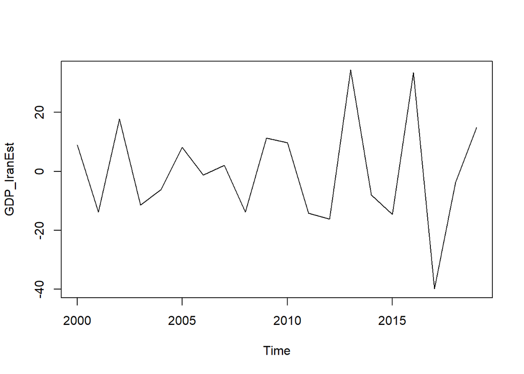

```r
GDP_IranEst<-diff((diff(diff(GDP_Iran))))
plot(GDP_IranEst,type="l")
```

```r
# GDP_World
adfGDPWo<-adf.test(GDP_World)
adfGDPWo
```

```
##
##  Augmented Dickey-Fuller Test
##
## data:  GDP_World
## Dickey-Fuller = -1.6693, Lag order = 2, p-value = 0.6984
## alternative hypothesis: stationary
```

```r
adf.test(diff(diff(GDP_World)))
```

```
##
##  Augmented Dickey-Fuller Test
##
## data:  diff(diff(GDP_World))
## Dickey-Fuller = -3.8124, Lag order = 2, p-value = 0.03483
## alternative hypothesis: stationary
```

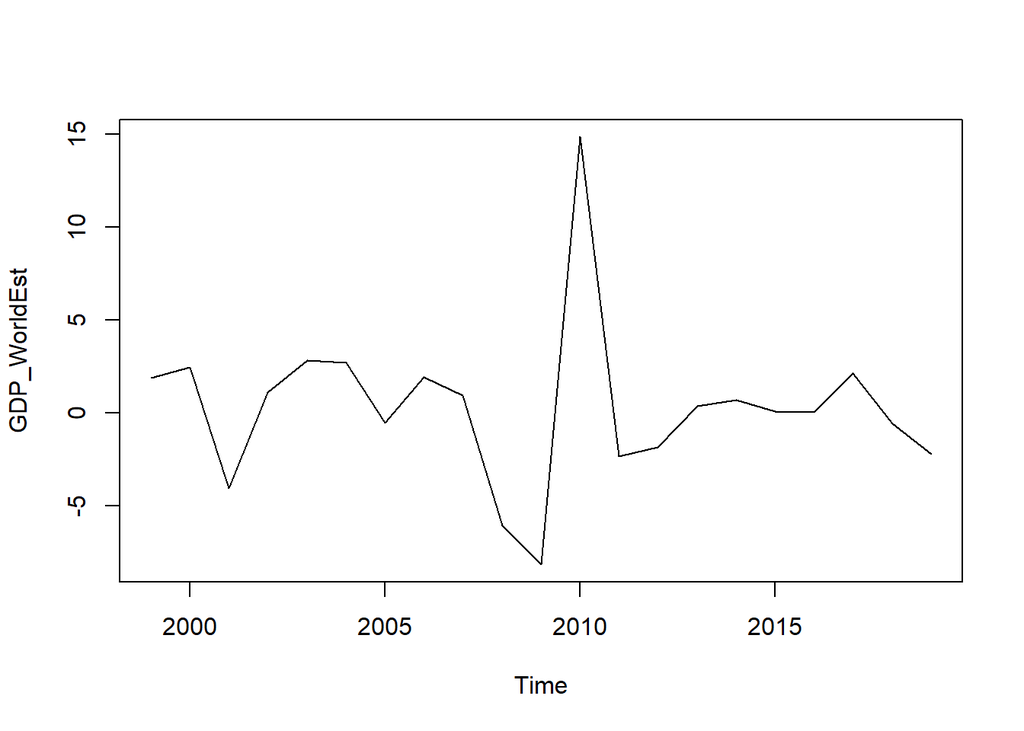

```r
GDP_WorldEst<-diff(diff(GDP_World))

plot(GDP_WorldEst)
```

```r
## Soja
# Juntando todas as variáveis

Soybase<-cbind(Exp_SoyEst,PSoyEst,GDP_ChinaEst,GDP_SpainEst,GDP_WorldEst)
Soybase<-replace(x = Soybase, list = is.na(Soybase), values = 0)
Soybase
```

```
## Time Series:
## Start = 1999
## End = 2019
## Frequency = 1
##      Exp_SoyEst     PSoyEst GDP_ChinaEst GDP_SpainEst GDP_WorldEst
## 1999  -1.067924   3.3702678    0.0000000    0.0000000   1.90217085
## 2000   3.212546  21.2964566    5.9848799    0.4027700   2.44988474
## 2001   1.132690  -8.4538031   -4.7947028   -2.7643778  -4.03046014
## 2002  -3.442190  12.9688943    6.3464539   -0.2562399   1.11410793
## 2003   3.265040   9.1248917    3.5150189    2.6863444   2.83802040
## 2004  -4.789652  -0.3301089   -3.6674064   -0.3422773   2.72514703
## 2005   6.082337 -36.5330940   11.5200900    1.0445064  -0.50223997
## 2006  -2.071094  18.0110543    6.1130886   -0.2889901   1.95530727
## 2007  -4.011105  39.7873722   10.7106969   -1.8729641   0.96245643
## 2008   2.039552  13.4771211  -79.3808595   -5.1346183  -6.05252995
## 2009   3.226632 -79.1583423   49.7358390   -4.9316918  -8.15490808
## 2010  -3.568569  30.4529948   26.1216954   20.0130479  14.87341176
## 2011   3.429379  35.0152090  -36.6335930  -11.4209117  -2.34671124
## 2012  -4.005841 -17.2566801  -14.7628788   -2.6131980  -1.85122742
## 2013   9.980795 -27.9191525   27.2867261    8.4519464   0.36416736
## 2014  -7.013353 -14.6362073   -9.3205228    2.3247529   0.69536642
## 2015   5.739329 -19.2478754    0.9659613   -0.7727929   0.08279783
## 2016 -11.344849  47.4186279    7.1842830   -6.6362624   0.06268433
## 2017  19.154597  -7.2494215    6.3070477    1.4371829   2.16010528
## 2018  -2.339992  -4.6786986   -8.1451721   -0.9545456  -0.56350680
## 2019 -25.912654   0.2901383  -14.0478117    0.1558059  -2.18492487
```

```r
# Lags ideal
lagselect<-vars::VARselect(Soybase,lag.max=12,type="both")
lagselect$selection # 2
```

```
## AIC(n)  HQ(n)  SC(n) FPE(n)
##      2      2      2      2
```

```r
# Teste de cointegração
cointest<-urca::ca.jo(Soybase, type="trace",K=2)
summary(cointest) # 4
```

```
##
## ######################
## # Johansen-Procedure #
## ######################
##
## Test type: trace statistic , with linear trend
##
## Eigenvalues (lambda):
## [1] 0.9631094 0.8692900 0.8024972 0.5682384 0.4468019
##
## Values of teststatistic and critical values of test:
##
##            test 10pct  5pct  1pct
## r <= 4 |  11.25  6.50  8.18 11.65
## r <= 3 |  27.21 15.66 17.95 23.52
## r <= 2 |  58.02 28.71 31.52 37.22
## r <= 1 |  96.69 45.23 48.28 55.43
## r = 0  | 159.38 66.49 70.60 78.87
##
## Eigenvectors, normalised to first column:
## (These are the cointegration relations)
##
##                 Exp_SoyEst.l2 PSoyEst.l2 GDP_ChinaEst.l2 GDP_SpainEst.l2
## Exp_SoyEst.l2      1.00000000  1.0000000      1.00000000      1.00000000
## PSoyEst.l2         0.01810549  0.6331116     -0.01640855      0.09168916
## GDP_ChinaEst.l2   -0.29115520  0.1412832     -0.08203649      0.92788526
## GDP_SpainEst.l2   -0.43113020  2.4111985      0.95404283     -1.93821605
## GDP_WorldEst.l2    0.76573522 -1.3981735     -0.69432360     -5.95053340
##                 GDP_WorldEst.l2
## Exp_SoyEst.l2          1.000000
## PSoyEst.l2            -2.125657
## GDP_ChinaEst.l2        3.353695
## GDP_SpainEst.l2      -19.150215
## GDP_WorldEst.l2       14.071396
##
## Weights W:
## (This is the loading matrix)
##
##                Exp_SoyEst.l2  PSoyEst.l2 GDP_ChinaEst.l2 GDP_SpainEst.l2
## Exp_SoyEst.d      -1.1680174 -0.30101253      -2.2783347      0.05177655
## PSoyEst.d         -2.4516090 -1.91020714       4.4169650      0.20202071
## GDP_ChinaEst.d     4.1372670 -3.18839094      -0.8277060      0.42992729
## GDP_SpainEst.d     0.6974845 -0.03445851      -0.5870229      0.17540653
## GDP_WorldEst.d    -0.1097549 -0.21844304       0.1259823      0.19641520
##                GDP_WorldEst.l2
## Exp_SoyEst.d       -0.07848568
## PSoyEst.d           0.36898803
## GDP_ChinaEst.d     -0.29629406
## GDP_SpainEst.d     -0.02850295
## GDP_WorldEst.d     -0.02178818
```

A quantidade de lags ideal para o modelo, seguindo o critério de informação sugerido pelo comando VArselect resultou em 2 lags. Como o teste de cointegração de Johansen resultou em 4 séries que podem estar correlacionadas, é necessário utilizar o modelo de correção VECM, conforme será apresentado abaixo.

```r
# Modelo VECM
library(tsDyn)
ModeloVCSoy<-VECM(Soybase,2,r=4, estim = "ML")
ModeloVCSoy
```

```
##                              ECT1        ECT2       ECT3      ECT4   Intercept
## Equation Exp_SoyEst   -0.60915124 -0.05879483 -1.6059811 -2.698104 -1.56680553
## Equation PSoyEst      -6.74329680  0.92072221  7.3767761 22.054441  9.07250805
## Equation GDP_ChinaEst -9.77112022  2.81527424  0.2157630 19.381812  5.22419643
## Equation GDP_SpainEst  0.01418188  0.48251410 -0.2802736  1.651895  0.06155739
## Equation GDP_WorldEst -1.35268781  0.66547245  0.5309121  4.649739  1.63546009
##                       Exp_SoyEst -1 PSoyEst -1 GDP_ChinaEst -1 GDP_SpainEst -1
## Equation Exp_SoyEst      -1.0882676 -0.1224220       1.3819120       -1.163402
## Equation PSoyEst          9.6966702 -0.5429170      -4.7464365      -11.766523
## Equation GDP_ChinaEst    13.3349503 -2.0875559      -0.5326411      -19.973560
## Equation GDP_SpainEst     0.4980013 -0.3528026       0.4231972       -2.778644
## Equation GDP_WorldEst     2.0008265 -0.4481626      -0.1531644       -4.094144
##                       GDP_WorldEst -1 Exp_SoyEst -2 PSoyEst -2 GDP_ChinaEst -2
## Equation Exp_SoyEst        -1.4259969    -1.1846630  0.1298789     1.009810564
## Equation PSoyEst           12.8576865     6.2323227 -1.0399454    -2.436898262
## Equation GDP_ChinaEst      10.7367877     7.2693429 -1.7307061     0.298540045
## Equation GDP_SpainEst       0.9952278     0.4959186 -0.1237114     0.202680338
## Equation GDP_WorldEst       2.6610721     1.2321910 -0.2903040    -0.009769998
##                       GDP_SpainEst -2 GDP_WorldEst -2
## Equation Exp_SoyEst         0.3169122      -2.2338995
## Equation PSoyEst           -8.2491848       7.3445839
## Equation GDP_ChinaEst      -7.7172979       1.2484540
## Equation GDP_SpainEst      -0.6254143      -0.4484317
## Equation GDP_WorldEst      -1.6343058       0.7407171
```

```r
summary(ModeloVCSoy)
```

```
## #############
## ###Model VECM
## #############
## Full sample size: 21     End sample size: 18
## Number of variables: 5   Number of estimated slope parameters 75
## AIC -Inf     BIC -Inf    SSR 804.2634
## Cointegrating vector (estimated by ML):
##       Exp_SoyEst      PSoyEst GDP_ChinaEst GDP_SpainEst GDP_WorldEst
## r1  1.000000e+00 5.551115e-17 5.551115e-17 4.440892e-16     1.428878
## r2  0.000000e+00 1.000000e+00 4.440892e-16 0.000000e+00   -10.950644
## r3  8.881784e-16 0.000000e+00 1.000000e+00 0.000000e+00    -6.323415
## r4 -4.440892e-16 5.551115e-17 1.665335e-16 1.000000e+00     1.610102
##
##
##                       ECT1                ECT2
## Equation Exp_SoyEst   -0.6092(0.9069)     -0.0588(0.3366)
## Equation PSoyEst      -6.7433(4.4571)     0.9207(1.6543)
## Equation GDP_ChinaEst -9.7711(3.5864).    2.8153(1.3311)
## Equation GDP_SpainEst 0.0142(0.8424)      0.4825(0.3127)
## Equation GDP_WorldEst -1.3527(0.4494).    0.6655(0.1668)*
##                       ECT3                ECT4
## Equation Exp_SoyEst   -1.6060(0.2983)*    -2.6981(2.3650)
## Equation PSoyEst      7.3768(1.4659)*     22.0544(11.6227)
## Equation GDP_ChinaEst 0.2158(1.1795)      19.3818(9.3521)
## Equation GDP_SpainEst -0.2803(0.2771)     1.6519(2.1967)
## Equation GDP_WorldEst 0.5309(0.1478)*     4.6497(1.1720)*
##                       Intercept           Exp_SoyEst -1
## Equation Exp_SoyEst   -1.5668(0.9491)     -1.0883(0.9862)
## Equation PSoyEst      9.0725(4.6643)      9.6967(4.8468)
## Equation GDP_ChinaEst 5.2242(3.7531)      13.3350(3.8999)*
## Equation GDP_SpainEst 0.0616(0.8815)      0.4980(0.9160)
## Equation GDP_WorldEst 1.6355(0.4703)*     2.0008(0.4887)*
##                       PSoyEst -1          GDP_ChinaEst -1
## Equation Exp_SoyEst   -0.1224(0.2082)     1.3819(0.2029)**
## Equation PSoyEst      -0.5429(1.0234)     -4.7464(0.9974)*
## Equation GDP_ChinaEst -2.0876(0.8234).    -0.5326(0.8025)
## Equation GDP_SpainEst -0.3528(0.1934)     0.4232(0.1885)
## Equation GDP_WorldEst -0.4482(0.1032)*    -0.1532(0.1006)
##                       GDP_SpainEst -1      GDP_WorldEst -1
## Equation Exp_SoyEst   -1.1634(1.7027)      -1.4260(1.0076)
## Equation PSoyEst      -11.7665(8.3680)     12.8577(4.9517).
## Equation GDP_ChinaEst -19.9736(6.7332).    10.7368(3.9843).
## Equation GDP_SpainEst -2.7786(1.5815)      0.9952(0.9359)
## Equation GDP_WorldEst -4.0941(0.8438)*     2.6611(0.4993)*
##                       Exp_SoyEst -2       PSoyEst -2
## Equation Exp_SoyEst   -1.1847(0.6412)     0.1299(0.1337)
## Equation PSoyEst      6.2323(3.1513)      -1.0399(0.6572)
## Equation GDP_ChinaEst 7.2693(2.5357).     -1.7307(0.5288)*
## Equation GDP_SpainEst 0.4959(0.5956)      -0.1237(0.1242)
## Equation GDP_WorldEst 1.2322(0.3178)*     -0.2903(0.0663)*
##                       GDP_ChinaEst -2     GDP_SpainEst -2
## Equation Exp_SoyEst   1.0098(0.1468)**    0.3169(0.7311)
## Equation PSoyEst      -2.4369(0.7215)*    -8.2492(3.5928)
## Equation GDP_ChinaEst 0.2985(0.5805)      -7.7173(2.8909).
## Equation GDP_SpainEst 0.2027(0.1364)      -0.6254(0.6790)
## Equation GDP_WorldEst -0.0098(0.0728)     -1.6343(0.3623)*
##                       GDP_WorldEst -2
## Equation Exp_SoyEst   -2.2339(0.5429)*
## Equation PSoyEst      7.3446(2.6683).
## Equation GDP_ChinaEst 1.2485(2.1470)
## Equation GDP_SpainEst -0.4484(0.5043)
## Equation GDP_WorldEst 0.7407(0.2691).
```

Os resultados do modelo não foram significativos para todas as variáveis envolvidas, mas foi em certo grau de significância, para algumas variáveis importantes como a própria variável defasada, o PIB da China e do Mundo. Agora, vamos fazer um diagnóstico do modelo, fazendo alguns testes antes de realizar a projeção.

```r
# Transformando o modelo VECM de volta para VAR

ModelVAR<-vec2var(cointest, r=4)

# Autocorrelação serial
serialtest<-serial.test(ModelVAR, lags.pt = 5)
serialtest # >0,05 não tem autocorrelação serial
```

```
##
##  Portmanteau Test (asymptotic)
##
## data:  Residuals of VAR object ModelVAR
## Chi-squared = 97.656, df = 80, p-value = 0.08748
```

```r
# Heterocedasticidade
archtest<-arch.test(ModelVAR, lags.multi = 3)
archtest # > que 0,05 não tem hetecedasticidade
```

```
##
##  ARCH (multivariate)
##
## data:  Residuals of VAR object ModelVAR
## Chi-squared = 240, df = 675, p-value = 1
```

```r
# distribuição normal dos resíduos
restest<-normality.test(ModelVAR, multivariate.only = TRUE)
restest # > que 0,05 os resíduos são normalmente distribuidos
```

```
## $JB
##
##  JB-Test (multivariate)
##
## data:  Residuals of VAR object ModelVAR
## Chi-squared = 5.9929, df = 10, p-value = 0.8159
##
##
## $Skewness
##
##  Skewness only (multivariate)
##
## data:  Residuals of VAR object ModelVAR
## Chi-squared = 4.156, df = 5, p-value = 0.5272
##
##
## $Kurtosis
##
##  Kurtosis only (multivariate)
##
## data:  Residuals of VAR object ModelVAR
## Chi-squared = 1.8369, df = 5, p-value = 0.8712
```

Considerando os resultados dos teste do modelo, a projeção segue abaixo. A variável de interesse é a Exp_SoyEst, que são as exportações em tons para os próximos 11 anos.

```r
# Forecast
forecastSoy<-predict(ModelVAR, n.ahead = 11)
forecastSoy
```

```
## $Exp_SoyEst
##              fcst       lower      upper       CI
##  [1,]   37.388254   26.581591  48.194918 10.80666
##  [2,]  -30.768700  -47.461904 -14.075496 16.69320
##  [3,]    5.981883  -12.591163  24.554929 18.57305
##  [4,]   28.740107    8.271462  49.208753 20.46865
##  [5,]  -61.695345  -84.851242 -38.539447 23.15590
##  [6,]   62.796198   33.073980  92.518416 29.72222
##  [7,]  -30.694712  -65.518815   4.129390 34.82410
##  [8,]  -29.503670  -65.414673   6.407332 35.91100
##  [9,]   89.515119   48.453478 130.576759 41.06164
## [10,] -121.018277 -171.798283 -70.238271 50.78001
## [11,]   84.688698   23.706860 145.670536 60.98184
##
## $PSoyEst
```

[output cut: 54 more lines]

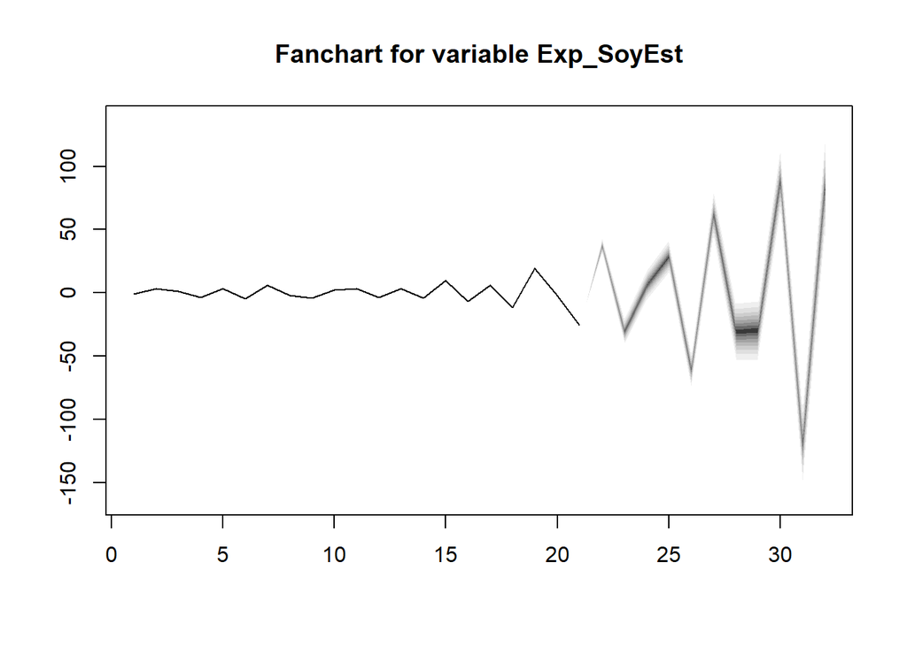

```r
fanchart(forecastSoy, names = "Exp_SoyEst")
```

A mesma estrutura é realizada para os dois produtos restantes:

```r
## Farelo de Soja
# Estacionariedade

# Exportações
adfExpSoyM<-adf.test(Exp_SoyMf)
adfExpSoyM
```

```
##
##  Augmented Dickey-Fuller Test
##
## data:  Exp_SoyMf
## Dickey-Fuller = -2.5671, Lag order = 2, p-value = 0.3563
## alternative hypothesis: stationary
```

```r
adf.test(diff(Exp_SoyMf))
```

```
##
##  Augmented Dickey-Fuller Test
##
## data:  diff(Exp_SoyMf)
## Dickey-Fuller = -2.8892, Lag order = 2, p-value = 0.2336
## alternative hypothesis: stationary
```

```r
adf.test(diff(diff(Exp_SoyMf)))
```

```
##
##  Augmented Dickey-Fuller Test
##
## data:  diff(diff(Exp_SoyMf))
## Dickey-Fuller = -3.2089, Lag order = 2, p-value = 0.1118
## alternative hypothesis: stationary
```

```r
adf.test(diff(diff(diff(Exp_SoyMf))))
```

```
##
##  Augmented Dickey-Fuller Test
##
## data:  diff(diff(diff(Exp_SoyMf)))
## Dickey-Fuller = -4.6517, Lag order = 2, p-value = 0.01
## alternative hypothesis: stationary
```

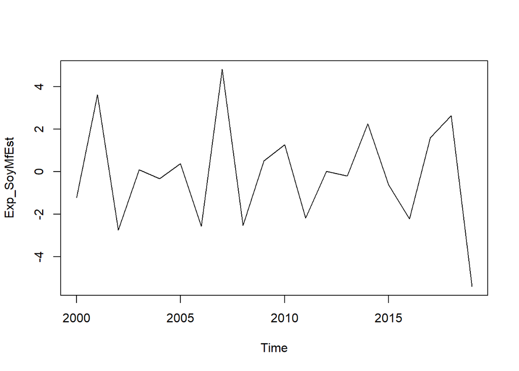

```r
Exp_SoyMfEst<-diff(diff(diff(Exp_SoyMf)))
plot(Exp_SoyMfEst)
```

```r
# Preço
adfPSoyM<-adf.test(PSoyM)
adfPSoyM
```

```
##
##  Augmented Dickey-Fuller Test
##
## data:  PSoyM
## Dickey-Fuller = -1.0243, Lag order = 2, p-value = 0.917
## alternative hypothesis: stationary
```

```r
adf.test(diff(PSoyM))
```

```
##
##  Augmented Dickey-Fuller Test
##
## data:  diff(PSoyM)
## Dickey-Fuller = -3.1588, Lag order = 2, p-value = 0.1309
## alternative hypothesis: stationary
```

```r
adf.test(diff(diff(PSoyM)))
```

```
##
##  Augmented Dickey-Fuller Test
##
## data:  diff(diff(PSoyM))
## Dickey-Fuller = -6.1929, Lag order = 2, p-value = 0.01
## alternative hypothesis: stationary
```

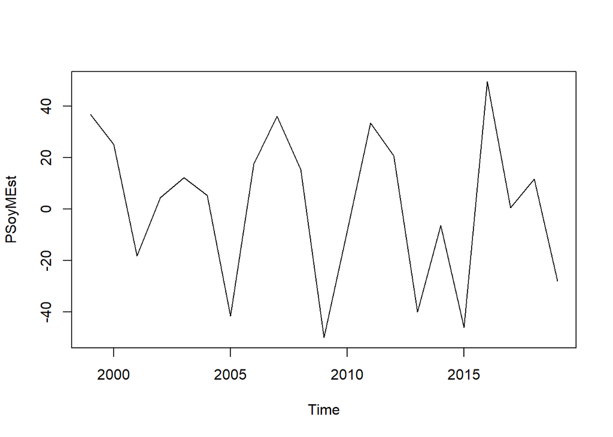

```r
PSoyMEst<-diff(diff(PSoyM))
plot(PSoyMEst)
```

```r
# Juntando todas as variáveis

SoyMbase<-cbind(Exp_SoyMfEst,PSoyMEst,GDP_NetherlandsEst,GDP_WorldEst)
SoyMbase<-replace(x = SoyMbase, list = is.na(SoyMbase), values = 0)
SoyMbase
```

```
## Time Series:
## Start = 1999
## End = 2019
## Frequency = 1
##      Exp_SoyMfEst    PSoyMEst GDP_NetherlandsEst GDP_WorldEst
## 1999   0.00000000  36.7709610          0.0000000   1.90217085
## 2000  -1.21708302  25.1531445         -1.7606591   2.44988474
## 2001   3.60957977 -18.2389502         -2.0846287  -4.03046014
## 2002  -2.74499000   4.3987577         -0.6380798   1.11410793
## 2003   0.10028316  12.0986564          3.6669342   2.83802040
## 2004  -0.32703698   5.2355326          3.2347085   2.72514703
## 2005   0.38412613 -41.5878900         -3.1635421  -0.50223997
## 2006  -2.55956345  17.5308249          2.8059287   1.95530727
## 2007   4.80879377  36.1130434         -2.0682480   0.96245643
## 2008  -2.52900384  15.3166636         -3.7439469  -6.05252995
## 2009   0.51941555 -50.0341012         -9.0800511  -8.15490808
## 2010   1.27760158  -8.5582209         22.1798067  14.87341176
## 2011  -2.18246116  33.4594009         -9.7314492  -2.34671124
## 2012   0.02174835  20.7721410         -5.4703794  -1.85122742
## 2013  -0.19133982 -40.0600566          6.8678348   0.36416736
## 2014   2.24794365  -6.3577706          1.1842246   0.69536642
## 2015  -0.61077864 -46.0427061         -1.7531545   0.08279783
## 2016  -2.22057469  49.4897376         -0.7650757   0.06268433
## 2017   1.60883571   0.4432155          1.0907049   2.16010528
## 2018   2.64452282  11.6324858         -2.0653347  -0.56350680
## 2019  -5.39310705 -28.1147634         -1.1696477  -2.18492487
```

```r
# Lags ideal
lagselect<-vars::VARselect(SoyMbase,lag.max=10,type="both")
lagselect$selection # 3
```

```
## AIC(n)  HQ(n)  SC(n) FPE(n)
##      3      3      3      3
```

```r
# Teste de cointegração
cointestSoyM<-urca::ca.jo(SoyMbase, type="trace",K=3)
summary(cointestSoyM) # r = 2
```

```
##
## ######################
## # Johansen-Procedure #
## ######################
##
## Test type: trace statistic , with linear trend
##
## Eigenvalues (lambda):
## [1] 0.9369832 0.8248781 0.7402428 0.2932145
##
## Values of teststatistic and critical values of test:
##
##            test 10pct  5pct  1pct
## r <= 3 |   6.25  6.50  8.18 11.65
## r <= 2 |  30.51 15.66 17.95 23.52
## r <= 1 |  61.87 28.71 31.52 37.22
## r = 0  | 111.63 45.23 48.28 55.43
##
## Eigenvectors, normalised to first column:
## (These are the cointegration relations)
##
##                       Exp_SoyMfEst.l3 PSoyMEst.l3 GDP_NetherlandsEst.l3
## Exp_SoyMfEst.l3             1.0000000  1.00000000            1.00000000
## PSoyMEst.l3                -0.1653158  0.01095033           -0.04936448
## GDP_NetherlandsEst.l3      -2.6275984  0.11560636            0.26533355
## GDP_WorldEst.l3             1.7927875  0.12650849            0.34618285
##                       GDP_WorldEst.l3
## Exp_SoyMfEst.l3            1.00000000
## PSoyMEst.l3                0.02122369
## GDP_NetherlandsEst.l3     -0.20733667
## GDP_WorldEst.l3            0.84500830
##
## Weights W:
## (This is the loading matrix)
##
##                      Exp_SoyMfEst.l3  PSoyMEst.l3 GDP_NetherlandsEst.l3
## Exp_SoyMfEst.d            -0.2109054  -4.69712242             0.7674055
## PSoyMEst.d                11.9068531 -17.77490946            21.7712467
## GDP_NetherlandsEst.d       0.7415027  -0.09645912            -3.1621138
## GDP_WorldEst.d             0.3081553  -0.53769988            -1.3862244
##                      GDP_WorldEst.l3
## Exp_SoyMfEst.d            -0.2584241
## PSoyMEst.d                -6.4529194
## GDP_NetherlandsEst.d       0.1178509
## GDP_WorldEst.d            -1.3153616
```

```r
# Modelo

# VECM
library(tsDyn)
ModelVECSoyM<-VECM(SoyMbase,3,r=2, estim = "ML")
ModelVECSoyM
```

```
##                                   ECT1        ECT2   Intercept Exp_SoyMfEst -1
## Equation Exp_SoyMfEst        -4.494839 -0.01030878 -0.12762493        1.881569
## Equation PSoyMEst           -33.279744  0.25090234 -2.54299396       24.044729
## Equation GDP_NetherlandsEst   4.442274  0.01903406  0.05089792       -4.590006
## Equation GDP_WorldEst         3.927351 -0.10179032 -0.38979432       -4.653781
##                              PSoyMEst -1 GDP_NetherlandsEst -1 GDP_WorldEst -1
## Equation Exp_SoyMfEst        0.044401722            -0.5967519      -0.1199004
## Equation PSoyMEst           -0.838161512           -21.9773308      17.7680084
## Equation GDP_NetherlandsEst -0.095103853            -1.2540070       0.3679285
## Equation GDP_WorldEst       -0.003402456             0.6808474      -1.3568508
##                             Exp_SoyMfEst -2 PSoyMEst -2 GDP_NetherlandsEst -2
## Equation Exp_SoyMfEst            0.06288864  0.02549125             0.1325880
## Equation PSoyMEst                9.49834767 -0.83181201           -14.5239556
## Equation GDP_NetherlandsEst     -4.62783033 -0.07428464            -0.3349260
## Equation GDP_WorldEst           -4.97621552 -0.05321749             0.8046882
##                             GDP_WorldEst -2 Exp_SoyMfEst -3 PSoyMEst -3
## Equation Exp_SoyMfEst            -0.9044510      -0.8611899  0.01186996
## Equation PSoyMEst                 6.1890528      -6.3955371 -0.46858356
## Equation GDP_NetherlandsEst      -0.6523707      -1.6553328  0.03054401
## Equation GDP_WorldEst            -1.2209090      -2.4304265  0.03088883
##                             GDP_NetherlandsEst -3 GDP_WorldEst -3
## Equation Exp_SoyMfEst                   0.3910900      -0.9781782
## Equation PSoyMEst                       0.1574682     -11.9033584
## Equation GDP_NetherlandsEst            -0.1435680      -0.3502102
## Equation GDP_WorldEst                   0.3861327      -0.7131156
```

```r
summary(ModelVECSoyM)
```

```
## #############
## ###Model VECM
## #############
## Full sample size: 21     End sample size: 17
## Number of variables: 4   Number of estimated slope parameters 60
## AIC -1073.539    BIC -1020.214   SSR 638.5847
## Cointegrating vector (estimated by ML):
##    Exp_SoyMfEst     PSoyMEst GDP_NetherlandsEst GDP_WorldEst
## r1            1 8.673617e-19         -0.1693366    0.1201696
## r2            0 1.000000e+00         10.5511115   -9.2209600
##
##
##                             ECT1                  ECT2
## Equation Exp_SoyMfEst       -4.4948(4.9681)       -0.0103(0.2573)
## Equation PSoyMEst           -33.2797(44.8011)     0.2509(2.3206)
## Equation GDP_NetherlandsEst 4.4423(8.0864)        0.0190(0.4189)
## Equation GDP_WorldEst       3.9274(3.5771)        -0.1018(0.1853)
##                             Intercept           Exp_SoyMfEst -1
## Equation Exp_SoyMfEst       -0.1276(0.6859)     1.8816(3.7241)
## Equation PSoyMEst           -2.5430(6.1855)     24.0447(33.5830)
## Equation GDP_NetherlandsEst 0.0509(1.1165)      -4.5900(6.0616)
## Equation GDP_WorldEst       -0.3898(0.4939)     -4.6538(2.6814)
##                             PSoyMEst -1         GDP_NetherlandsEst -1
## Equation Exp_SoyMfEst       0.0444(0.1606)      -0.5968(3.6170)
## Equation PSoyMEst           -0.8382(1.4482)     -21.9773(32.6173)
## Equation GDP_NetherlandsEst -0.0951(0.2614)     -1.2540(5.8873)
## Equation GDP_WorldEst       -0.0034(0.1156)     0.6808(2.6043)
##                             GDP_WorldEst -1      Exp_SoyMfEst -2
## Equation Exp_SoyMfEst       -0.1199(2.8585)      0.0629(1.9366)
## Equation PSoyMEst           17.7680(25.7772)     9.4983(17.4637)
## Equation GDP_NetherlandsEst 0.3679(4.6527)       -4.6278(3.1521)
## Equation GDP_WorldEst       -1.3569(2.0582)      -4.9762(1.3944).
##                             PSoyMEst -2         GDP_NetherlandsEst -2
## Equation Exp_SoyMfEst       0.0255(0.0954)      0.1326(1.7318)
## Equation PSoyMEst           -0.8318(0.8600)     -14.5240(15.6170)
## Equation GDP_NetherlandsEst -0.0743(0.1552)     -0.3349(2.8188)
## Equation GDP_WorldEst       -0.0532(0.0687)     0.8047(1.2469)
##                             GDP_WorldEst -2     Exp_SoyMfEst -3
## Equation Exp_SoyMfEst       -0.9045(0.8275)     -0.8612(1.0865)
## Equation PSoyMEst           6.1891(7.4623)      -6.3955(9.7983)
## Equation GDP_NetherlandsEst -0.6524(1.3469)     -1.6553(1.7686)
## Equation GDP_WorldEst       -1.2209(0.5958)     -2.4304(0.7823).
##                             PSoyMEst -3         GDP_NetherlandsEst -3
## Equation Exp_SoyMfEst       0.0119(0.0559)      0.3911(0.4709)
## Equation PSoyMEst           -0.4686(0.5041)     0.1575(4.2466)
## Equation GDP_NetherlandsEst 0.0305(0.0910)      -0.1436(0.7665)
## Equation GDP_WorldEst       0.0309(0.0403)      0.3861(0.3391)
##                             GDP_WorldEst -3
## Equation Exp_SoyMfEst       -0.9782(1.4082)
## Equation PSoyMEst           -11.9034(12.6991)
## Equation GDP_NetherlandsEst -0.3502(2.2921)
## Equation GDP_WorldEst       -0.7131(1.0140)
```

```r
# Diagnóstico do modelo

# Transformando VECM em VAR

ModelVARSoyM<-vec2var(cointestSoyM, r=2)

# Autocorrelação serial
serialtestSoyM<-serial.test(ModelVARSoyM, lags.pt = 10)
serialtestSoyM # > 0,05 não tem autocorrelação serial
```

```
##
##  Portmanteau Test (asymptotic)
##
## data:  Residuals of VAR object ModelVARSoyM
## Chi-squared = 112.61, df = 116, p-value = 0.5718
```

```r
# Heterocedasticidade
archtest<-arch.test(ModelVARSoyM, lags.multi = 7)
archtest # > que 0,05 não tem hetecedasticidade
```

```
##
##  ARCH (multivariate)
##
## data:  Residuals of VAR object ModelVARSoyM
## Chi-squared = 110, df = 700, p-value = 1
```

```r
# distribuição normal dos resíduos
ResSoyM<-normality.test(ModelVARSoyM, multivariate.only = TRUE)
ResSoyM # > 0,05 é normalmente distribuido
```

```
## $JB
##
##  JB-Test (multivariate)
##
## data:  Residuals of VAR object ModelVARSoyM
## Chi-squared = 10.003, df = 8, p-value = 0.2648
##
##
## $Skewness
##
##  Skewness only (multivariate)
##
## data:  Residuals of VAR object ModelVARSoyM
## Chi-squared = 8.5714, df = 4, p-value = 0.07275
##
##
## $Kurtosis
##
##  Kurtosis only (multivariate)
##
## data:  Residuals of VAR object ModelVARSoyM
## Chi-squared = 1.4312, df = 4, p-value = 0.8387
```

```r
# Forecast
forecastSoyM<-predict(ModelVARSoyM, n.ahead = 11)
forecastSoyM
```

```
## $Exp_SoyMfEst
##             fcst       lower      upper       CI
##  [1,]  1.6374945  0.04993957  3.2250493 1.587555
##  [2,]  0.8892866 -1.70666180  3.4852351 2.595948
##  [3,] -3.1072369 -5.91522187 -0.2992519 2.807985
##  [4,] -0.5935311 -3.66126534  2.4742031 3.067734
##  [5,]  2.4799873 -0.96690383  5.9268785 3.446891
##  [6,] -1.8103784 -5.28932555  1.6685688 3.478947
##  [7,] -3.2756130 -6.92277896  0.3715529 3.647166
##  [8,]  1.8930201 -1.77043769  5.5564779 3.663458
##  [9,]  1.1114243 -2.68622474  4.9090733 3.797649
## [10,] -4.6906777 -8.53421049 -0.8471450 3.843533
## [11,]  0.8588641 -3.13218210  4.8499102 3.991046
##
## $PSoyMEst
```

[output cut: 40 more lines]

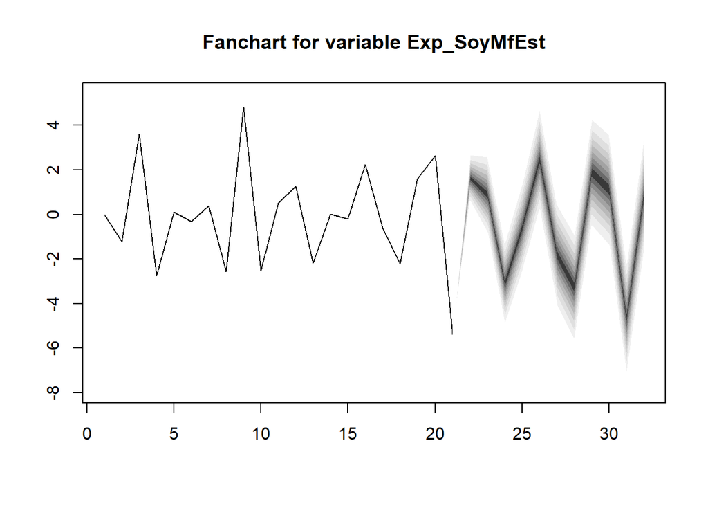

```r
fanchart(forecastSoyM, names = "Exp_SoyMfEst")
```

```r
## Milho
# Estacionariedade

# Exportações
adfExpCorn<-adf.test(Exp_Corn)
adfExpCorn
```

```
##
##  Augmented Dickey-Fuller Test
##
## data:  Exp_Corn
## Dickey-Fuller = -1.5968, Lag order = 2, p-value = 0.726
## alternative hypothesis: stationary
```

```r
adf.test(diff(Exp_Corn))
```

```
##
##  Augmented Dickey-Fuller Test
##
## data:  diff(Exp_Corn)
## Dickey-Fuller = -3.1621, Lag order = 2, p-value = 0.1297
## alternative hypothesis: stationary
```

```r
adf.test(diff(diff(Exp_Corn)))
```

```
##
##  Augmented Dickey-Fuller Test
##
## data:  diff(diff(Exp_Corn))
## Dickey-Fuller = -3.7123, Lag order = 2, p-value = 0.04198
## alternative hypothesis: stationary
```

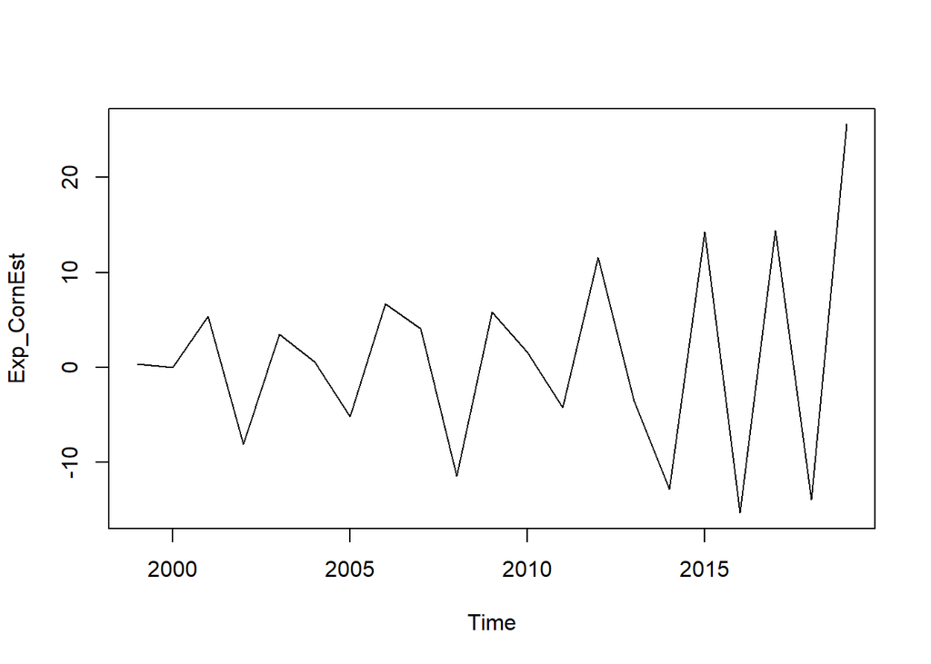

```r
Exp_CornEst<-diff(diff(Exp_Corn))
plot(Exp_CornEst)
```

```r
# Preço
adfPrCorn<-adf.test(PCorn)
adfPrCorn
```

```
##
##  Augmented Dickey-Fuller Test
##
## data:  PCorn
## Dickey-Fuller = -1.1729, Lag order = 2, p-value = 0.8875
## alternative hypothesis: stationary
```

```r
adf.test(diff(PCorn))
```

```
##
##  Augmented Dickey-Fuller Test
##
## data:  diff(PCorn)
## Dickey-Fuller = -2.6071, Lag order = 2, p-value = 0.3411
## alternative hypothesis: stationary
```

```r
adf.test(diff(diff(PCorn)))
```

```
##
##  Augmented Dickey-Fuller Test
##
## data:  diff(diff(PCorn))
## Dickey-Fuller = -4.042, Lag order = 2, p-value = 0.02179
## alternative hypothesis: stationary
```

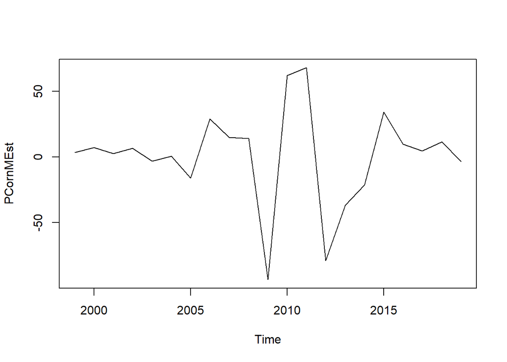

```r
PCornMEst<-diff(diff(PCorn))
plot(PCornMEst)
```

```r
# PIBs
#GDP_Vietnam
adfGDPVi<-adf.test(GDP_Vietnam)
adfGDPVi
```

```
##
##  Augmented Dickey-Fuller Test
##
## data:  GDP_Vietnam
## Dickey-Fuller = 2.9709, Lag order = 2, p-value = 0.99
## alternative hypothesis: stationary
```

```r
adf.test(diff(GDP_Vietnam))
```

```
##
##  Augmented Dickey-Fuller Test
##
## data:  diff(GDP_Vietnam)
## Dickey-Fuller = -0.016715, Lag order = 2, p-value = 0.99
## alternative hypothesis: stationary
```

```r
adf.test(diff(diff(GDP_Vietnam)))
```

```
##
##  Augmented Dickey-Fuller Test
##
## data:  diff(diff(GDP_Vietnam))
## Dickey-Fuller = -2.1786, Lag order = 2, p-value = 0.5044
## alternative hypothesis: stationary
```

```r
adf.test(diff(diff(diff(GDP_Vietnam))))
```

```
##
##  Augmented Dickey-Fuller Test
##
## data:  diff(diff(diff(GDP_Vietnam)))
## Dickey-Fuller = -4.8525, Lag order = 2, p-value = 0.01
## alternative hypothesis: stationary
```

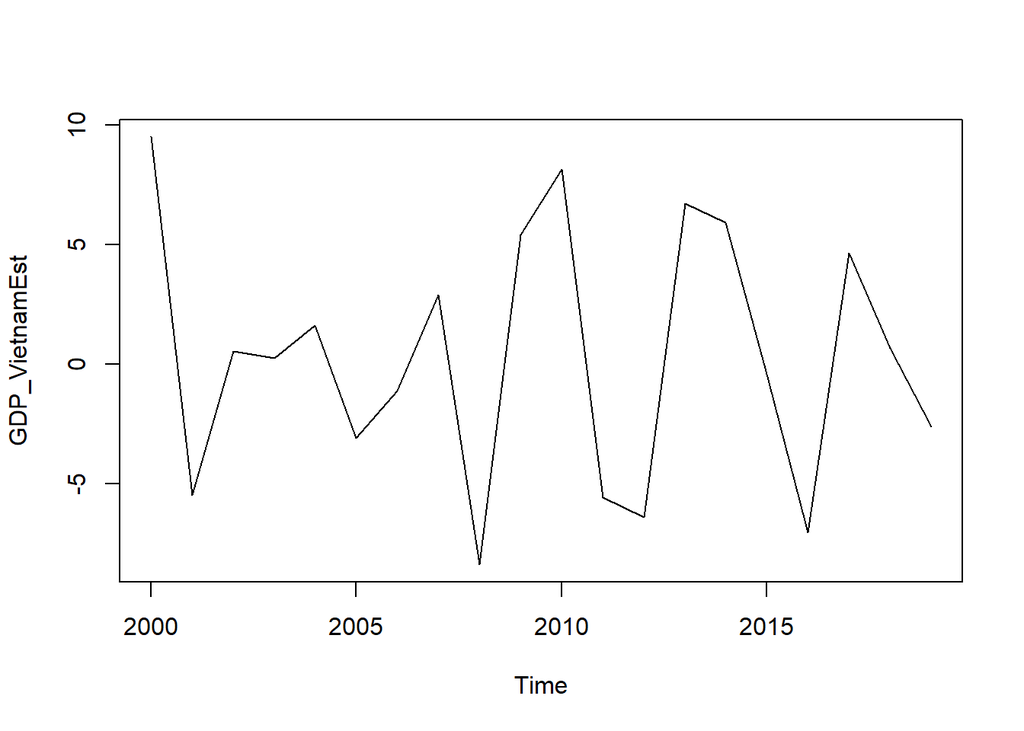

```r
GDP_VietnamEst<-(diff(diff(diff(GDP_Vietnam))))
plot(GDP_VietnamEst)
```

```r
# GDP_Japan
adfGDPJp<-adf.test(GDP_Japan)
adfGDPJp
```

```
##
##  Augmented Dickey-Fuller Test
##
## data:  GDP_Japan
## Dickey-Fuller = -2.2716, Lag order = 2, p-value = 0.4689
## alternative hypothesis: stationary
```

```r
adf.test(diff(GDP_Japan))
```

```
##
##  Augmented Dickey-Fuller Test
##
## data:  diff(GDP_Japan)
## Dickey-Fuller = -2.5474, Lag order = 2, p-value = 0.3639
## alternative hypothesis: stationary
```

```r
adf.test(diff(diff(GDP_Japan)))
```

```
##
##  Augmented Dickey-Fuller Test
##
## data:  diff(diff(GDP_Japan))
## Dickey-Fuller = -3.4613, Lag order = 2, p-value = 0.06926
## alternative hypothesis: stationary
```

```r
adf.test(diff(diff(diff(GDP_Japan))))
```

```
##
##  Augmented Dickey-Fuller Test
##
## data:  diff(diff(diff(GDP_Japan)))
## Dickey-Fuller = -4.4776, Lag order = 2, p-value = 0.01
## alternative hypothesis: stationary
```

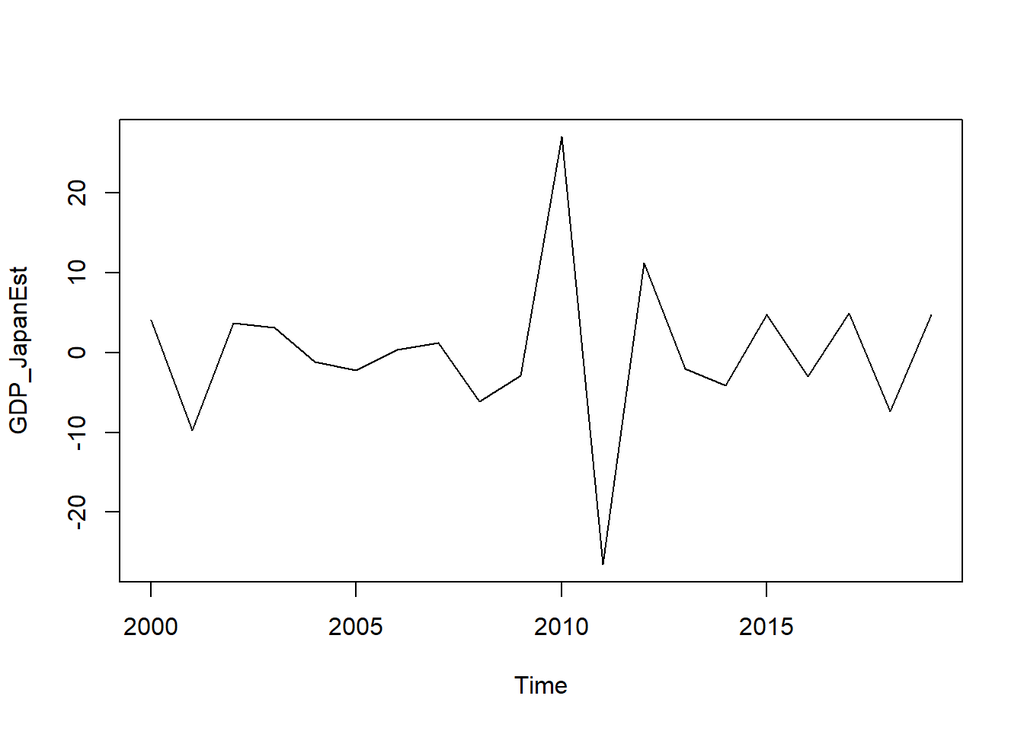

```r
GDP_JapanEst<-diff(diff(diff(GDP_Japan)))
plot(GDP_JapanEst)
```

```r
# GDP_Egypt
adfGDPEg<-adf.test(GDP_Egypt)
adfGDPEg
```

```
##
##  Augmented Dickey-Fuller Test
##
## data:  GDP_Egypt
## Dickey-Fuller = -2.0084, Lag order = 2, p-value = 0.5692
## alternative hypothesis: stationary
```

```r
adf.test(diff(GDP_Egypt))
```

```
##
##  Augmented Dickey-Fuller Test
##
## data:  diff(GDP_Egypt)
## Dickey-Fuller = -2.3635, Lag order = 2, p-value = 0.4339
## alternative hypothesis: stationary
```

```r
adf.test(diff(diff(GDP_Egypt)))
```

```
##
##  Augmented Dickey-Fuller Test
##
## data:  diff(diff(GDP_Egypt))
## Dickey-Fuller = -1.801, Lag order = 2, p-value = 0.6482
## alternative hypothesis: stationary
```

```r
adf.test(diff(diff(diff(GDP_Egypt))))
```

```
##
##  Augmented Dickey-Fuller Test
##
## data:  diff(diff(diff(GDP_Egypt)))
## Dickey-Fuller = -2.1656, Lag order = 2, p-value = 0.5093
## alternative hypothesis: stationary
```

```r
adf.test(diff(diff(diff(diff(GDP_Egypt)))))
```

```
##
##  Augmented Dickey-Fuller Test
##
## data:  diff(diff(diff(diff(GDP_Egypt))))
## Dickey-Fuller = -3.4951, Lag order = 2, p-value = 0.06456
## alternative hypothesis: stationary
```

```r
adf.test(diff(diff(diff(diff(diff(GDP_Egypt))))))
```

```
##
##  Augmented Dickey-Fuller Test
##
## data:  diff(diff(diff(diff(diff(GDP_Egypt)))))
## Dickey-Fuller = -5.8299, Lag order = 2, p-value = 0.01
## alternative hypothesis: stationary
```

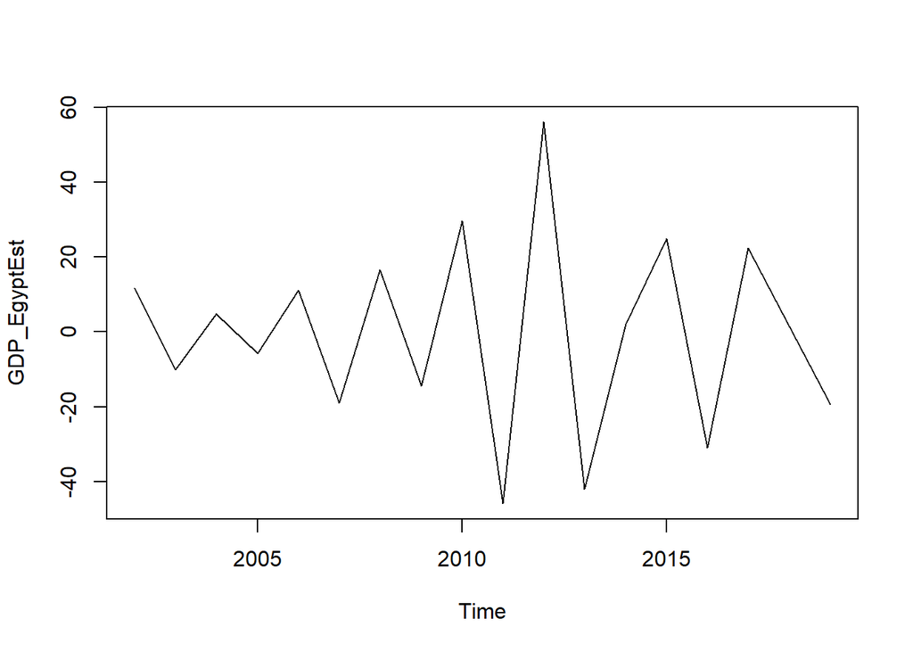

```r
GDP_EgyptEst<-diff(diff(diff(diff(diff(GDP_Egypt)))))
plot(GDP_EgyptEst)
```

```r
GDP_WorldEst
```

```
## Time Series:
## Start = 1999
## End = 2019
## Frequency = 1
##  [1]  1.90217085  2.44988474 -4.03046014  1.11410793  2.83802040  2.72514703
##  [7] -0.50223997  1.95530727  0.96245643 -6.05252995 -8.15490808 14.87341176
## [13] -2.34671124 -1.85122742  0.36416736  0.69536642  0.08279783  0.06268433
## [19]  2.16010528 -0.56350680 -2.18492487
```

```r
GDP_IranEst
```

```
## Time Series:
## Start = 2000
## End = 2019
## Frequency = 1
##  [1]   8.922672 -13.826283  17.809049 -11.379464  -6.099636   8.129633
##  [7]  -1.156370   2.028230 -13.839626  11.291592   9.749305 -14.142490
## [13] -16.094660  34.397130  -7.971267 -14.582089  33.514647 -39.826894
## [19]  -3.767139  14.847615
```

```r
# Juntando todas as variáveis

Cornbase<-cbind(Exp_CornEst,PCornMEst,GDP_IranEst,GDP_VietnamEst,GDP_JapanEst)
Cornbase<-replace(x = Cornbase, list = is.na(Cornbase), values = 0)
Cornbase
```

```
## Time Series:
## Start = 1999
## End = 2019
## Frequency = 1
##        Exp_CornEst   PCornMEst GDP_IranEst GDP_VietnamEst GDP_JapanEst
## 1999   0.350148819   3.3653666    0.000000      0.0000000     0.000000
## 2000   0.000946247   7.3570217    8.922672      9.5199943     4.060742
## 2001   5.384024410   2.7560120  -13.826283     -5.4740742    -9.750691
## 2002  -8.053210576   6.6294115   17.809049      0.5558590     3.695892
## 2003   3.457827605  -3.0322614  -11.379464      0.2761306     3.116294
## 2004   0.593577863   0.5865663   -6.099636      1.6168178    -1.224161
## 2005  -5.205189867 -15.9381005    8.129633     -3.0964059    -2.206717
## 2006   6.689594889  29.0551736   -1.156370     -1.1227896     0.335866
## 2007   4.104315608  14.9724624    2.028230      2.8929442     1.152609
## 2008 -11.448276176  14.1492912  -13.839626     -8.3800229    -6.159995
## 2009   5.827970296 -93.4507064   11.291592      5.4148879    -2.932723
## 2010   1.627198668  62.0924932    9.749305      8.1733052    26.972548
## 2011  -4.258100045  68.0657438  -14.142490     -5.5816157   -26.546088
## 2012  11.596899502 -78.9988862  -16.094660     -6.3902284    11.150496
## 2013  -3.502546885 -36.6235063   34.397130      6.7268734    -2.080604
## 2014 -12.794563756 -21.1446297   -7.971267      5.9330502    -4.172250
## 2015  14.250400428  34.1608777  -14.582089     -0.3975920     4.761783
## 2016 -15.306091533   9.9199374   33.514647     -7.0489109    -3.022585
## 2017  14.426824851   4.7708498  -39.826894      4.6620068     4.901984
## 2018 -13.898950967  11.5671655   -3.767139      0.6823844    -7.391244
## 2019  25.592716834  -3.3863606   14.847615     -2.6186415     4.736518
```

```r
# Lags ideal
lagselect<-vars::VARselect(Cornbase,lag.max = 10,type="both")
lagselect$selection # 2
```

```
## AIC(n)  HQ(n)  SC(n) FPE(n)
##      2      2      2      2
```

```r
# Teste de cointegração
cointestCorn<-urca::ca.jo(Cornbase, type="trace",K=2)
summary(cointestCorn) #r = 4
```

```
##
## ######################
## # Johansen-Procedure #
## ######################
##
## Test type: trace statistic , with linear trend
##
## Eigenvalues (lambda):
## [1] 0.9899285 0.9590878 0.8190047 0.6424520 0.4557514
##
## Values of teststatistic and critical values of test:
##
##            test 10pct  5pct  1pct
## r <= 4 |  11.56  6.50  8.18 11.65
## r <= 3 |  31.10 15.66 17.95 23.52
## r <= 2 |  63.58 28.71 31.52 37.22
## r <= 1 | 124.31 45.23 48.28 55.43
## r = 0  | 211.67 66.49 70.60 78.87
##
## Eigenvectors, normalised to first column:
## (These are the cointegration relations)
##
##                   Exp_CornEst.l2 PCornMEst.l2 GDP_IranEst.l2 GDP_VietnamEst.l2
## Exp_CornEst.l2         1.0000000   1.00000000     1.00000000         1.0000000
## PCornMEst.l2          -0.6400887  -0.30524364    -0.02934887         0.3644138
## GDP_IranEst.l2        -3.0307109  -0.03340282     0.07042653        -0.5657607
## GDP_VietnamEst.l2      1.7002358  -2.41397509     1.17548879        -1.5507565
## GDP_JapanEst.l2       -1.9639887   0.82240616     1.08557512         0.4900023
##                   GDP_JapanEst.l2
## Exp_CornEst.l2         1.00000000
## PCornMEst.l2           0.01515725
## GDP_IranEst.l2         0.22586707
## GDP_VietnamEst.l2      0.26787409
## GDP_JapanEst.l2       -1.31684796
##
## Weights W:
## (This is the loading matrix)
##
##                  Exp_CornEst.l2 PCornMEst.l2 GDP_IranEst.l2 GDP_VietnamEst.l2
## Exp_CornEst.d      -0.002170869   -0.7060015     -0.8359318        -0.2240883
## PCornMEst.d         0.074906349   -0.2018668      1.2488950        -2.7172520
## GDP_IranEst.d       0.707396937    0.1195628     -0.3837894         0.2814770
## GDP_VietnamEst.d   -0.041731270    0.6000758     -0.5823670        -0.0160809
## GDP_JapanEst.d      0.041169741   -0.2594712     -0.9704222        -0.2875389
##                  GDP_JapanEst.l2
## Exp_CornEst.d        -1.29978681
## PCornMEst.d           0.06073782
## GDP_IranEst.d        -0.14876011
## GDP_VietnamEst.d     -0.22840604
## GDP_JapanEst.d        0.31825942
```

```r
# Modelo
# VECM

library(tsDyn)
ModelVECCorn<-VECM(Cornbase,2,r=4, estim = "ML")
ModelVECCorn
```

```
##                                ECT1       ECT2        ECT3       ECT4
## Equation Exp_CornEst     -2.8021761 -0.3377864 -3.32747096  0.5786438
## Equation PCornMEst      -13.6237039  1.5781258 -4.01931331 21.7251525
## Equation GDP_IranEst      1.2314389 -0.2062989 -0.25095975 -2.5820218
## Equation GDP_VietnamEst  -0.9918088 -0.1077739 -0.06794003 -1.4371457
## Equation GDP_JapanEst    -3.0355419  0.4078711  0.79360983  2.1896739
##                            Intercept Exp_CornEst -1 PCornMEst -1 GDP_IranEst -1
## Equation Exp_CornEst    -0.422784890      0.8760314   0.36996174     2.28498350
## Equation PCornMEst       0.777798224     12.8149576  -1.54637901     5.32508445
## Equation GDP_IranEst    -0.305847554     -0.3823924   0.11559611    -0.62763538
## Equation GDP_VietnamEst  0.007269561      0.6613959   0.01547219    -0.04648993
## Equation GDP_JapanEst    0.194096601      2.3886162  -0.36761269    -0.24593413
##                         GDP_VietnamEst -1 GDP_JapanEst -1 Exp_CornEst -2
## Equation Exp_CornEst          -0.11930567       1.3674153      0.7911129
## Equation PCornMEst            -8.27137358       5.5801802      5.6028707
## Equation GDP_IranEst           0.61521380      -0.5376091     -0.8505280
## Equation GDP_VietnamEst       -0.01721228       0.3076000      0.4421140
## Equation GDP_JapanEst         -0.86912495       0.3407209      0.7238111
##                         PCornMEst -2 GDP_IranEst -2 GDP_VietnamEst -2
## Equation Exp_CornEst      0.32424103     1.19959732       -0.48311240
## Equation PCornMEst       -0.60959086     3.76413559       -0.34189628
## Equation GDP_IranEst     -0.14998118    -0.84737220        1.23856393
## Equation GDP_VietnamEst  -0.03600851     0.08997885       -0.33669319
## Equation GDP_JapanEst    -0.18836897    -0.06533404       -0.06030396
##                         GDP_JapanEst -2
## Equation Exp_CornEst          0.4260850
## Equation PCornMEst           -0.1976488
## Equation GDP_IranEst         -0.5746380
## Equation GDP_VietnamEst       0.1762163
## Equation GDP_JapanEst        -0.1223526
```

```r
summary(ModelVECCorn)
```

```
## #############
## ###Model VECM
## #############
## Full sample size: 21     End sample size: 18
## Number of variables: 5   Number of estimated slope parameters 75
## AIC NaN  BIC NaN     SSR 1206.932
## Cointegrating vector (estimated by ML):
##      Exp_CornEst     PCornMEst   GDP_IranEst GDP_VietnamEst GDP_JapanEst
## r1  1.000000e+00  0.000000e+00 -2.775558e-16   1.110223e-16    0.4166137
## r2  8.326673e-16  1.000000e+00 -1.221245e-15  -4.440892e-16  -10.4259495
## r3  8.326673e-17 -3.816392e-17  1.000000e+00   5.551115e-17    1.4174149
## r4 -1.249001e-16 -1.387779e-17 -1.665335e-16   1.000000e+00    0.7805373
##
##
##                         ECT1                ECT2
## Equation Exp_CornEst    -2.8022(2.0085)     -0.3378(0.4094)
## Equation PCornMEst      -13.6237(3.6642)*   1.5781(0.7468)
## Equation GDP_IranEst    1.2314(0.5441)      -0.2063(0.1109)
## Equation GDP_VietnamEst -0.9918(0.7634)     -0.1078(0.1556)
## Equation GDP_JapanEst   -3.0355(0.6572)*    0.4079(0.1339).
##                         ECT3                ECT4
## Equation Exp_CornEst    -3.3275(2.1085)     0.5786(4.1774)
## Equation PCornMEst      -4.0193(3.8465)     21.7252(7.6209).
## Equation GDP_IranEst    -0.2510(0.5712)     -2.5820(1.1317)
## Equation GDP_VietnamEst -0.0679(0.8014)     -1.4371(1.5877)
## Equation GDP_JapanEst   0.7936(0.6899)      2.1897(1.3669)
##                         Intercept           Exp_CornEst -1
## Equation Exp_CornEst    -0.4228(2.4504)     0.8760(1.5439)
## Equation PCornMEst      0.7778(4.4704)      12.8150(2.8166)*
## Equation GDP_IranEst    -0.3058(0.6638)     -0.3824(0.4182)
## Equation GDP_VietnamEst 0.0073(0.9313)      0.6614(0.5868)
## Equation GDP_JapanEst   0.1941(0.8018)      2.3886(0.5052)*
##                         PCornMEst -1       GDP_IranEst -1
## Equation Exp_CornEst    0.3700(0.3477)     2.2850(1.5363)
## Equation PCornMEst      -1.5464(0.6344).   5.3251(2.8027)
## Equation GDP_IranEst    0.1156(0.0942)     -0.6276(0.4162)
## Equation GDP_VietnamEst 0.0155(0.1322)     -0.0465(0.5839)
## Equation GDP_JapanEst   -0.3676(0.1138)*   -0.2459(0.5027)
##                         GDP_VietnamEst -1   GDP_JapanEst -1
## Equation Exp_CornEst    -0.1193(2.4517)     1.3674(1.5873)
## Equation PCornMEst      -8.2714(4.4728)     5.5802(2.8958)
## Equation GDP_IranEst    0.6152(0.6642)      -0.5376(0.4300)
## Equation GDP_VietnamEst -0.0172(0.9318)     0.3076(0.6033)
## Equation GDP_JapanEst   -0.8691(0.8022)     0.3407(0.5194)
##                         Exp_CornEst -2     PCornMEst -2
## Equation Exp_CornEst    0.7911(1.0048)     0.3242(0.2188)
## Equation PCornMEst      5.6029(1.8332).    -0.6096(0.3991)
## Equation GDP_IranEst    -0.8505(0.2722).   -0.1500(0.0593).
## Equation GDP_VietnamEst 0.4421(0.3819)     -0.0360(0.0832)
## Equation GDP_JapanEst   0.7238(0.3288)     -0.1884(0.0716).
##                         GDP_IranEst -2      GDP_VietnamEst -2
## Equation Exp_CornEst    1.1996(0.8163)      -0.4831(1.2445)
## Equation PCornMEst      3.7641(1.4892).     -0.3419(2.2704)
## Equation GDP_IranEst    -0.8474(0.2211)*    1.2386(0.3371)*
## Equation GDP_VietnamEst 0.0900(0.3103)      -0.3367(0.4730)
## Equation GDP_JapanEst   -0.0653(0.2671)     -0.0603(0.4072)
##                         GDP_JapanEst -2
## Equation Exp_CornEst    0.4261(0.6746)
## Equation PCornMEst      -0.1976(1.2306)
## Equation GDP_IranEst    -0.5746(0.1827).
## Equation GDP_VietnamEst 0.1762(0.2564)
## Equation GDP_JapanEst   -0.1224(0.2207)
```

```r
# Diagnóstico do modelo

# Transformando VECM em VAR

ModelVARCorn<-vec2var(cointestCorn, r=4)

# Autocorrelação serial
serialtestCorn<-serial.test(ModelVARCorn, lags.pt = 10)
serialtestCorn # > 0,05 não tem autocorrelação serial
```

```
##
##  Portmanteau Test (asymptotic)
##
## data:  Residuals of VAR object ModelVARCorn
## Chi-squared = 227.03, df = 205, p-value = 0.1392
```

```r
# Heterocedasticidade
archtestCorn<-arch.test(ModelVARCorn, lags.multi = 3)
archtestCorn # > que 0,05 não tem hetecedasticidade
```

```
##
##  ARCH (multivariate)
##
## data:  Residuals of VAR object ModelVARCorn
## Chi-squared = 240, df = 675, p-value = 1
```

```r
# distribuição normal dos resíduos
ResCorn<-normality.test(ModelVARCorn, multivariate.only = TRUE)
ResCorn # > 0,05 é normalmente distribuido
```

```
## $JB
##
##  JB-Test (multivariate)
##
## data:  Residuals of VAR object ModelVARCorn
## Chi-squared = 11.057, df = 10, p-value = 0.3531
##
##
## $Skewness
##
##  Skewness only (multivariate)
##
## data:  Residuals of VAR object ModelVARCorn
## Chi-squared = 4.9175, df = 5, p-value = 0.426
##
##
## $Kurtosis
##
##  Kurtosis only (multivariate)
##
## data:  Residuals of VAR object ModelVARCorn
## Chi-squared = 6.1397, df = 5, p-value = 0.2929
```

```r
# Forecast
forecastCorn<-predict(ModelVARCorn, n.ahead = 11, lambda = 0)
forecastCorn
```

```
## $Exp_CornEst
##              fcst      lower     upper       CI
##  [1,] -17.3984656 -29.440603 -5.356329 12.04214
##  [2,]  12.0018732  -2.518919 26.522665 14.52079
##  [3,]   0.4395797 -17.855890 18.735050 18.29547
##  [4,]   3.7691585 -15.212082 22.750399 18.98124
##  [5,]  -6.4877310 -26.736030 13.760569 20.24830
##  [6,]  17.0731100  -3.462166 37.608386 20.53528
##  [7,]  -6.9140653 -28.492257 14.664127 21.57819
##  [8,]   4.1907224 -17.492661 25.874106 21.68338
##  [9,]  -2.0573244 -25.049793 20.935144 22.99247
## [10,]  19.3942673  -3.698405 42.486940 23.09267
## [11,] -17.0411104 -41.467087  7.384866 24.42598
##
## $PCornMEst
```

[output cut: 54 more lines]

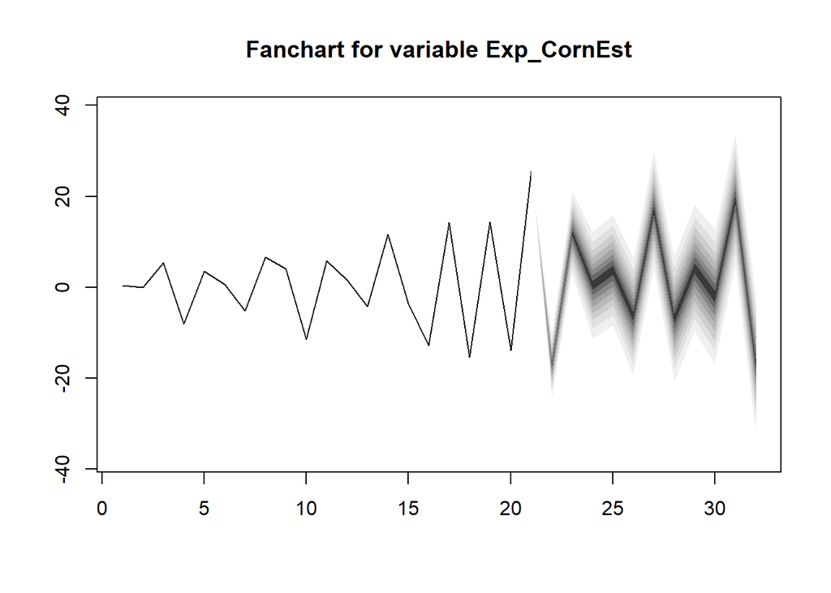

```r
fanchart(forecastCorn, names = "Exp_CornEst")
```